# Operating Model for approximating GRYM for the Antarctic krill (*Euphausia superba*) in southwest Atlantic (FAO Area 48.1)

# Introduction

This is an example of implementing the current krill fishery management strategy using the “umbrella” MSE package [`{openMSE}`](https://openmse.com/).

### Inherent differences between `{openMSE}` and `{Grym}`

#### Starting age-class and age of recruitment

In GRYM’s base application to krill, the stock is modelled using seven age-classes taking age-1 as the starting age-class, i.e. for age ranges 1-2, 2-3, …, 6-7 and 7-8. This choice of age-classes is based on the fact that krill is not expected to live long past 7 years, while krill younger than 1 year old are rarely seen in survey data (Maschette and Wotherspoon, 2021). Thus, under GRYM, krill is assumed to recruit to the modelled stock at age-1.

Under `{openMSE}`, **however**, the population dynamics model is structured as `maxage`+1 age classes, with recruitment modelled to occur at age-0. Currently `{openMSE}` does not offer the option to change the age of the first modelled age-class.

Age of recruitment (0 vs 1) and number of age-classes (8 vs 7) assumed under each framework are therefore different.

#### Length-at-age distribution

GRYM does not account for variation in length-at-age, implying that all individuals follow exactly the average growth curve.

Trial runs in `{openMSE}` showed simulations crashing if variation in length-at-age was set to zero. A minimum level of variation in length-at-age was used.

**Note**: some warning messages are shown during simulations when low variation in length-at-age is assumed. For the purpose of the approximation to GRYM, these warnings can be ignored.

#### Historical period

In GRYM, stock projections start from a pre-exploitation state, ignoring information on historical and current status of the fishery. This option is not available in `{openMSE}`, as it enforces the simulation of an historical period of length `nyears` leading up to a current state, from which the stock projected forward by applying each MP under evaluation. Trial runs showed that the MSE simulation crashes when `nyears` is less than 5 years.

#### Annual Recruitment

GRYM projections do not account for strict stock-recruitment relationships, i.e. the strength of annual recruitments are **mostly** assumed to be independent of precedent levels of spawning stock biomass. Annual numbers of recruits are at first simulated by generating random deviates from a mean recruitment of 1 and variance estimated from the variability in the proportion of recruits observed in multiple surveys (Maschette and Wotherspoon, 2021). This is called the Proportional Recruitment (PR) method (Pavez et al., 2021). However, GRYM imposes a constraint on the level of recruitment if the population is depleted, in which case the simulated value of recruitment value is multiplied the proportion of current SSB below the depletion level ($SSB/(0.2 \times SSB0)$).

`{openMSE}` relies on a strict stock-recruitment relationship and so there appears to be no option for constraining recruitment strength based on the level of depletion. In fact, by assuming steepness of 1, `{openMSE}` further deviates from GRYM when simulated populations fall below depletion levels.

# Operating Model

## Species Information

**Species**: *Euphausia superba*

**Common Name**: *Antarctic Krill*

**Management Agency**: CCAMLR

**Region**: FAO Area 48

**Sponsor**: Norwegian Polar Institute

**Latitude**: -60

**Longitude**: -40

## OM Parameters

**OM Name**: Name of the operating model: krill_grym_approx_scn-1

**proyears**: The number of projected years: 50

**interval**: The assessment interval - how often would you like to update the management system? 1

**pstar**: The percentile of the sample of the management recommendation for each method: 0.5

**maxF**: Maximum instantaneous fishing mortality rate that may be simulated for any given age class: 1.5

**reps**: Number of samples of the management recommendation for each method. Note that when this is set to 1, the mean value of the data inputs is used. 1

**Source**: A reference to a website or article from which parameters were taken to define the operating model

# Custom Parameters

## `M` and `Perr`

Specific simulation values used for Natural Mortality (**M**) and recruitment variability (**Perr**), both from as random draws of `M` and coefficient of variation of recruitment (`R_CV`) obtained from the Proportional Recruitment (PR) model currently applied to Krill under GRYM assessments (Pavez et al, 2021).

For this `OM`, simulated values of `M` and `R_CV` were generated using PR inputs provided in Maschette et al (2021), specifically those identified as “initial parameters”, i.e.:

- Mean proportional recruitment: 0.5570
- SD of proportional recruitment: 0.126
- Nr. of surveys: 17
- Reference age-class: 2

Obtained draws `R_CV` were converted to log-normal standard deviations ($SD = \sqrt{log(CV^2 + 1)}$) and plugged in as simulation values of `Perr`.

Note: `{openMSE}` seems to simulate recruitments as $R_y = \mu_R \times d_R, d_R \sim logN \left( \frac{\texttt{-Perr}^2}{2}, \texttt{Perr}^2 \right)$

## Age-plus group

From code provided in [GYM’s base case for krill](https://github.com/ccamlr/Grym_Base_Case/tree/Simulations), population dynamics functions (e.g. `Grym::ageStructureS`) are run with argument `plus = FALSE`., i.e. the final age-class is not treated as an age-plus class.

`{openMSE}` defaults to use the maximum age-class `maxage` as a plus group. So, to approximate to Krill’s base case, the plus group needs to be switched off by setting the custom parameter `OM@cpars$plusgroup=0`.

# Stock Parameters

### Mortality and age: maxage, R0, M, Msd

**maxage**: The maximum age of individuals that is simulated. There are maxage+1 (recruitment to age-0) age classes in the storage matrices. maxage is the plus group where all age-classes > maxage are grouped, unless option switched off with OM@cpars$plusgroup=0 . Single value. Positive integer.

Specified Value(s): 7

Maximum age chosen for consistency with GRYM’s application (Maschette et al., 2021), where the final age-class covers ages 7 - 8.

**R0**: Initial number of unfished recruits to age-0. This number is used to scale the size of the population to match catch or data, but does not affect any of the population dynamics unless the OM has been conditioned with data. As a result, for a data-limited fishery any number can be used for R0 . In data-rich stocks R0 may be estimated as part of a stock assessment, but for data limited stocks users can choose either an arbitrary number (say, 1000) or choose a number that produces simulated catches in recent historical years that are similar to real world catch data. Single value. Positive real number.

Specified Value(s): 1

Adopting same value as the mean recruitment assumed in krill assessment under GRYM.

**M**: The instantaneous rate of natural mortality. For each simulation a single value is drawn from a uniform distribution specified by the upper and lower bounds provided. Uniform distribution lower and upper bounds. Non-negative real numbers.

Specified in cpars: 0.563, 1.291

Simulation values for `M` provided in cpars (see Custom Parameters). The text above about `M` being drawn from an uniform distribution should be ignored.

**Msd**: Inter-annual variation in M expressed as a coefficient of variation of a log-normal distribution. For each simulation a single value is drawn from a uniform distribution specified by the upper and lower bounds provided. If this parameter is positive, yearly M is drawn from a log-normal distribution with a mean specified by log(M) drawn for that simulation and a standard deviation in log space specified by the value of Msd drawn for that simulation. Uniform distribution lower and upper bounds. Non-negative real numbers

Specified Value(s): 0, 0

Similarly to Krill’s GRYM application, assuming natural mortality is constant over time.

### Natural Mortality Parameters

#### Sampled Parameters

Histograms of simulations of `M`, and `Msd` parameters, with vertical colored lines indicating 3 randomly drawn values used in other plots:

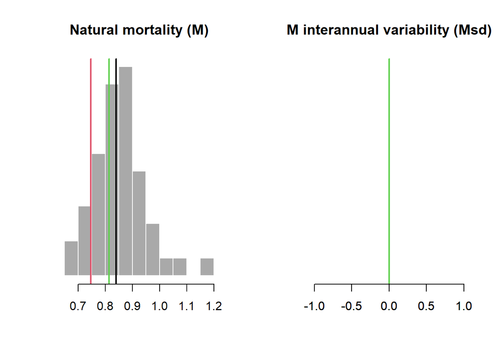

#### Time-Series

The average natural mortality rate by year for adult fish for 3 simulations. The vertical dashed line indicates the end of the historical period:

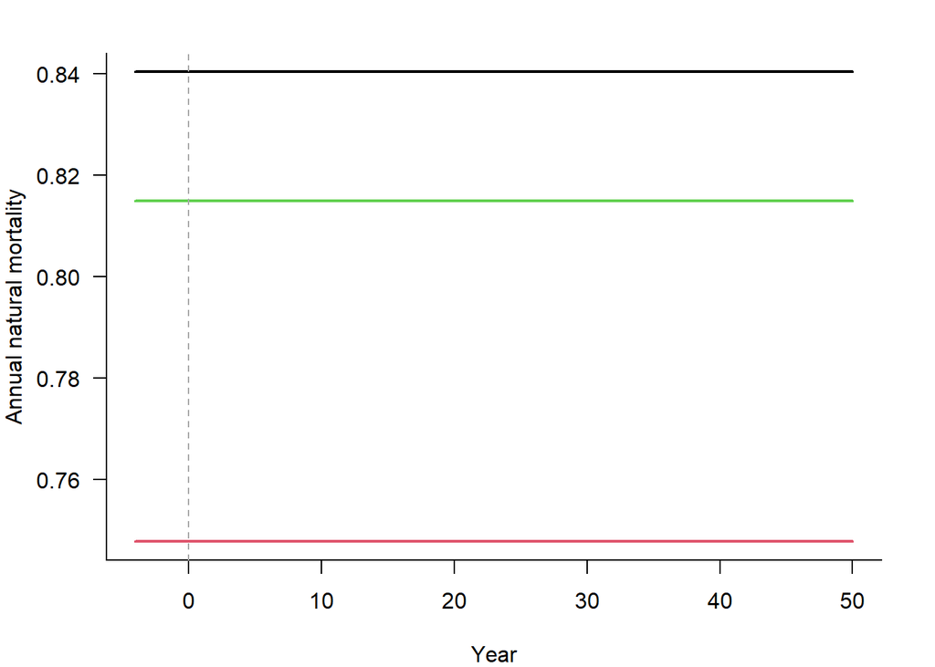

#### M-at-Age

Natural mortality-at-age for 3 simulations in the first historical year, the last historical year (i.e., current year), and the last projected year:

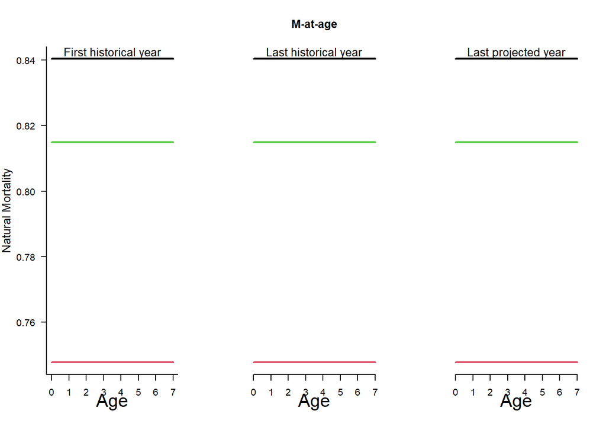

#### M-at-Length

Natural mortality-at-length for 3 simulations in the first historical year, the last historical year (i.e., current year), and the last projected year:

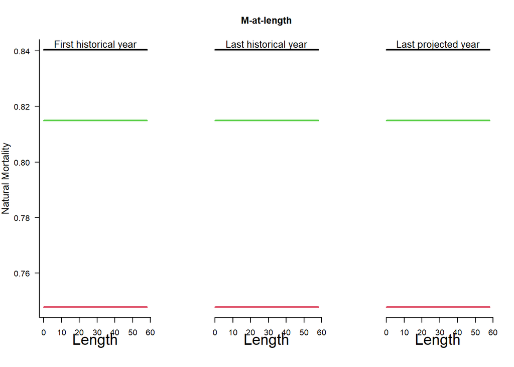

### Recruitment: h, SRrel, Perr, AC

**h**: Steepness of the stock recruit relationship. Steepness governs the proportion of unfished recruits produced when the stock is at 20% of the unfished population size. For each simulation a single value is drawn from a uniform distribution specified by the upper and lower bounds provided. This value is the same in all years of a given simulation. Uniform distribution lower and upper bounds. Values from 1/5 to 1.

Specified Value(s): 1, 1

Studies have failed to show a strong correlation between spawning biomass and subsequent recruitment in krill populations (Siegel and Loeb, 1995; Kinzey et al., 2019). This is mainly due to large inter-annual variability in biomass of spawners and recruits, which are thought to be strongly driven by environmental factors.

GRYM projections do not account for stock-recruitment relationships, instead simulating annual recruitment by sampling from a probability distribution with mean and variance estimated from recruitment levels observed in acoustic surveys (check Section Annual Recruitment for more details).

`{openMSE}` does not offer the option to simulate recruits from a user-defined sampling distribution. Instead, mean recruitments $\mu_R$ are calculated from a stock-recruitment relationship defined by steepness `h`, which are in turn used to generate annual numbers of recruits $R_y$ from recruitment deviations $d_R$ following a lognormal process error, i.e. (?):

$$R_y = \mu_R \times d_R, d_R \sim logN
\left( -\frac{\texttt{Perr}^2}{2}, \texttt{Perr}^2 \right)$$
if correlation in recruitments between consecutive years is ignored.

Thus, fixing `h = 1` (i.e. forcing stock-recruitment independence) and using the recruitment variance estimates from PR as `Perr` inputs should provide a good approximation of `{openMSE}` to GRYM in terms of recruitment simulation.

Note: assuming `h = 1` implies high resilience of the population to strong harvesting, presenting a high probability of rebuilding when fishing pressure is relaxed even at low stock sizes.

**SRrel**: Type of stock-recruit relationship. Use 1 to select a Beverton Holt relationship, 2 to select a Ricker relationship. Single value. Integer

Specified Value(s): 1

Beverton–Holt model, to force stock-recruitment independence for `h = 1`. The Ricker model imposes a density dependence in the stock-recruitment process regardless of the value `h`.

**Perr**: Recruitment process error, which is defined as the standard deviation of the recruitment deviations in log space. For each simulation a single value is drawn from a uniform distribution specified by the upper and lower bounds provided. Uniform distribution lower and upper bounds. Non-negative real numbers.

Specified in cpars: 0.255, 1.183

Simulation values for `Perr` provided in cpars (see Custom Parameters). The text above about values being drawn from an uniform distribution should be ignored.

**AC**: Autocorrelation in the recruitment deviations in log space. For each simulation a single value is drawn from a uniform distribution specified by the upper and lower bounds provided, and used to add lag-1 auto-correlation to the log recruitment deviations. Uniform distribution lower and upper bounds. Non-negative real numbers.

Specified Value(s): 0, 0

Assuming no autocorrelation between consecutive annual recruitments, i.e. following the same approach as Krill’s GRYM base case.

### Recruitment Parameters

#### Sampled Parameters

Histograms of 48 simulations of steepness (`h`), recruitment process error (`Perr`) and auto-correlation (`AC`) for the Beverton-Holt stock-recruitment relationship, with vertical colored lines indicating 3 randomly drawn values used in other plots:

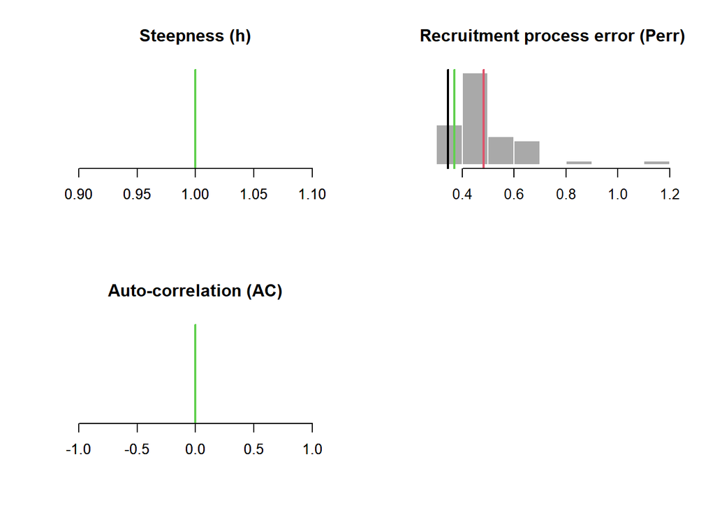

#### Time-Series

Time-series plot showing 3 samples of recruitment deviations for historical and projection years:

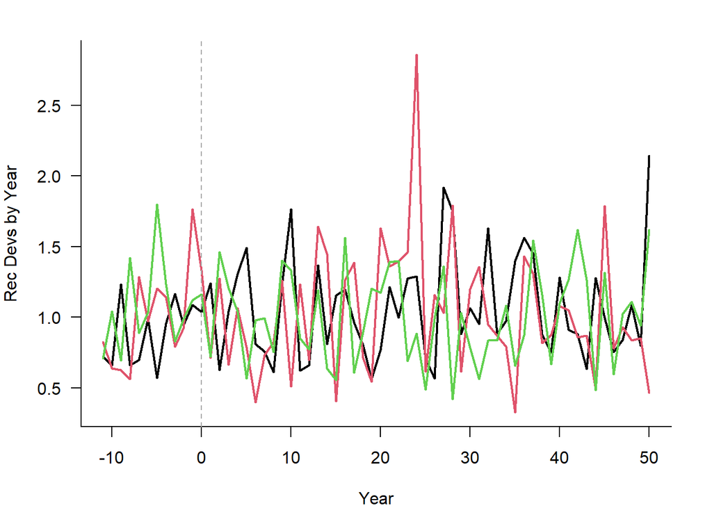

### Growth: Linf, K, t0, LenCV, Ksd, Linfsd

**Linf**: The von Bertalanffy growth parameter Linf, which specifies the average maximum size that would reached by adult fish if they lived indefinitely. For each simulation a single value is drawn from a uniform distribution specified by the upper and lower bounds provided. This value is the same in all years unless Linfsd is a positive number. Uniform distribution lower and upper bounds. Positive real numbers.

Specified Value(s): 60, 60

$L_\infty$ parameter assumed as known (i.e. no uncertainty), as in GRYM. Same $L_\infty$ value (mm) as used in Maschette et al. (2021) analysis, which cite Constable and de la Mare (1996).

**K**: The von Bertalanffy growth parameter k, which specifies the average rate of growth. For each simulation a single value is drawn from a uniform distribution specified by the upper and lower bounds provided. This value is the same in all years unless Ksd is a positive number. Uniform distribution lower and upper bounds. Positive real numbers.

Specified Value(s): 0.48, 0.48

Growth parameter $K$ assumed as known (i.e. no uncertainty), as in GRYM. Same $K$ as used in Maschette et al. (2021) analysis, which cite Thanassekos et al (2021).

**t0**: The von Bertalanffy growth parameter t0, which specifies the theoretical age at a size 0. For each simulation a single value is drawn from a uniform distribution specified by the upper and lower bounds provided. Uniform distribution lower and upper bounds. Non-positive real numbers.

Specified Value(s): 0, 0

Age at size-0 assumed as known (i.e. no uncertainty), as in GRYM. Same parameter value as used in Maschette et al. (2021) analysis, which cite Thanassekos et al (2021).

**LenCV**: The coefficient of variation (defined as the standard deviation divided by mean) of the length-at-age. For each simulation a single value is drawn from a uniform distribution specified by the upper and lower bounds provided to specify the distribution of observed length-at-age, and the CV of this distribution is constant for all age classes (i.e, standard deviation increases proportionally with the mean). Uniform distribution lower and upper bounds. Positive real numbers.

Specified Value(s): 0.01, 0.01

Assuming low variation in length-at-age - see Section Length-at-age distribution above. Also, variation in length-at-age treated as known (i.e. no uncertainty and hence fixed across simulations).

**Ksd**: Inter-annual variation in K. For each simulation a single value is drawn from a uniform distribution specified by the upper and lower bounds provided. If this parameter has a positive value, yearly K is drawn from a log-normal distribution with a mean specified by the value of K drawn for that simulation and a standard deviation (in log space) specified by the value of Ksd drawn for that simulation. Uniform distribution lower and upper bounds. Non-negative real numbers.

Specified Value(s): 0, 0

As in GRYM, assuming no inter-annual variation in in growth parameter $K$.

**Linfsd**: Inter-annual variation in Linf. For each simulation a single value is drawn from a uniform distribution specified by the upper and lower bounds provided. If this parameter has a positive value, yearly Linf is drawn from a log-normal distribution with a mean specified by the value of Linf drawn for that simulation and a standard deviation (in log space) specified by the value of Linfsd drawn for that simulation. Uniform distribution lower and upper bounds. Non-negative real numbers.

Specified Value(s): 0, 0

As in GRYM, assuming no inter-annual variation in $L_\infty$.

### Growth Parameters

#### Sampled Parameters

Histograms of simulations of von Bertalanffy growth parameters `Linf`, `K`, and `t0`, and inter-annual variability in Linf and K (`Linfsd` and `Ksd`), with vertical colored lines indicating 3 randomly drawn values used in other plots:

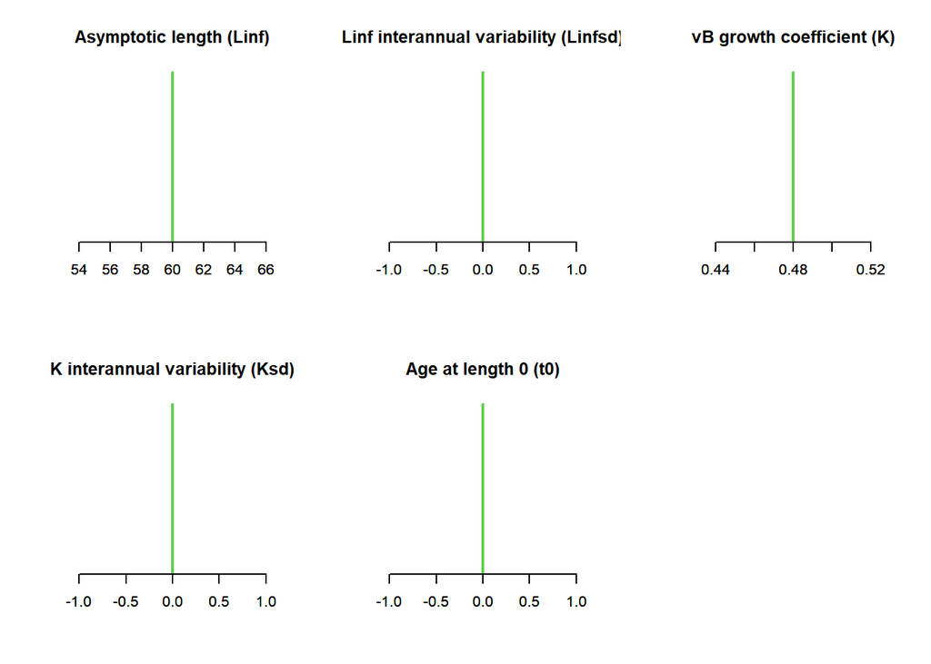

#### Time-Series

The Linf and K parameters in each year for 3 simulations. The vertical dashed line indicates the end of the historical period:

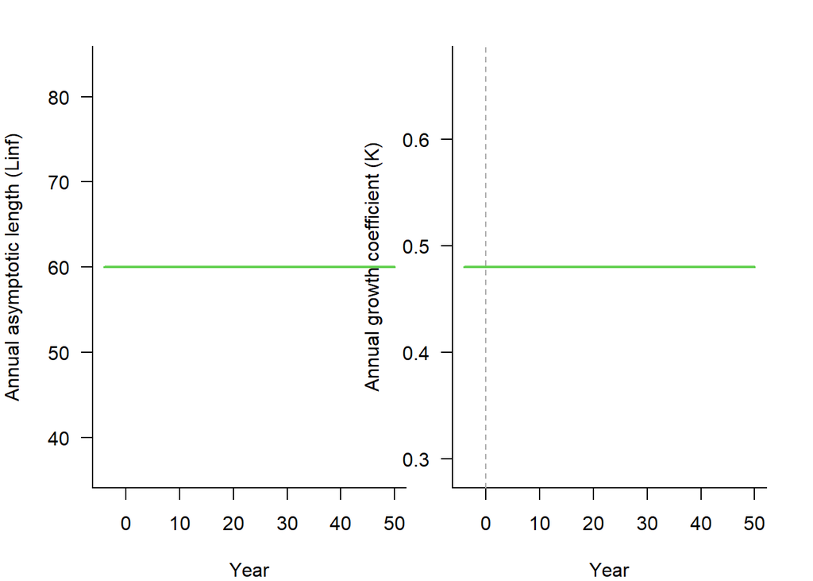

#### Growth Curves

Sampled length-at-age curves for 3 simulations in the first historical year, the last historical year, and the last projection year.

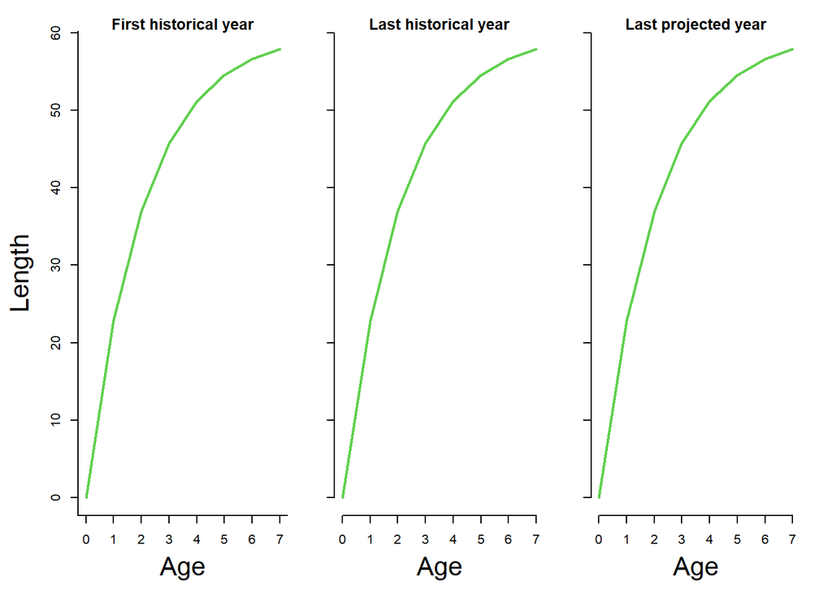

### Maturity: L50, L50_95

**L50**: Length at 50% maturity. For each simulation a single value is drawn from a uniform distribution specified by the upper and lower bounds provided. The L50 and L50_95 parameters are converted to ages using the growth parameters provided and used to construct a logistic curve to determine the proportion of the population that is mature in each age class. Uniform distribution lower and upper bounds. Positive real numbers.

Same values as Min and Max length (mm) at 50% maturity used in Maschette et al. (2021) analysis - specifically the ‘initial values’ used for size at maturity.

**L50_95**: Difference in lengths between 50% and 95% maturity. For each simulation a single value is drawn from a uniform distribution specified by the upper and lower bounds provided. The value drawn is then added to the length at 50% maturity to determine the length at 95% maturity. This parameterization is used instead of specifying the size at 95 percent maturity to avoid situations where the value drawn for the size at 95% maturity is smaller than that at 50% maturity. The L50 and L50_95 parameters are converted to ages using the growth parameters provided and used to construct a logistic curve to determine the proportion of the population that is mature in each age class. Uniform distribution lower and upper bounds. Positive real numbers.

Specified Value(s): 2.7, 2.7

GRYM formulates size-at-maturity using the ogive ramp function specified in terms `L50` and the ramp’s width `w` (i.e. the range at which maturity occurs).

Thus, `L95` (length at which 95% of individuals are matures) can be derived via the quantile function of the uniform distribution with limits `L50 +- w/2`. For a (known) width of 6mm, used as ‘initial value’ in Maschette et al (2021), we get the required `L50_95` parameter value.

```r
w <- 6
L50 <- 35 # arbitrary as `w` is treated as independent of L50 in Maschette et al (2021)
L95 <- qunif(0.95, L50 - w/2, L50 + w/2)
L95 - L50
```

```
## [1] 2.7
```

Similarly to GRYM, where `w` is treated as known, `L50_95` is also kept fixed across simulations.

### Maturity Parameters

#### Sampled Parameters

Histograms of simulations of `L50` (length at 50% maturity), and `L95` (length at 95% maturity), with vertical colored lines indicating 3 randomly drawn values used in other plots:

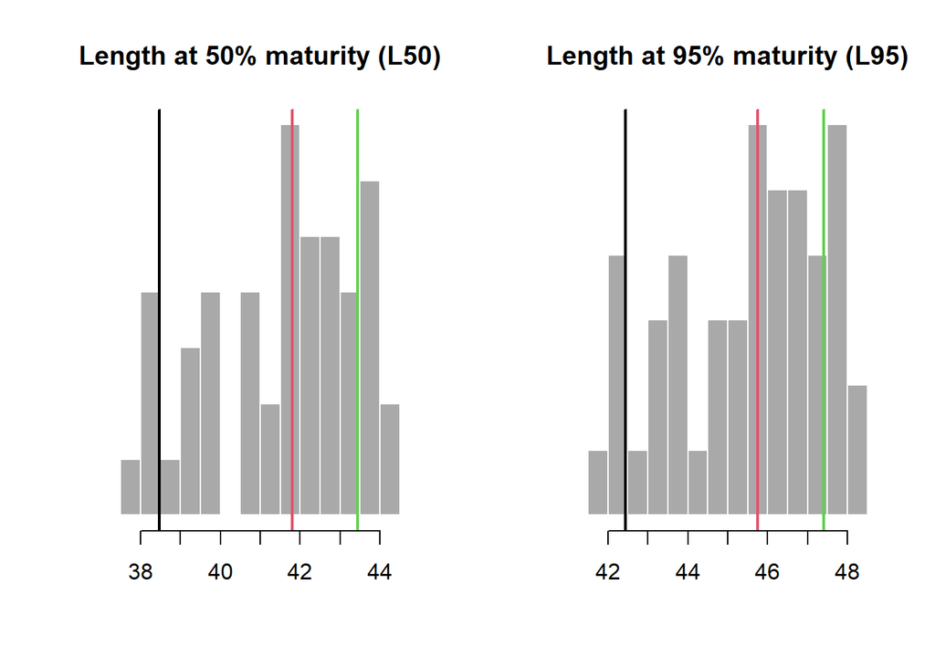

#### Maturity at Age and Length

Maturity-at-age and -length for 3 simulations in the first historical year, the last historical year (i.e., current year), and the last projected year:

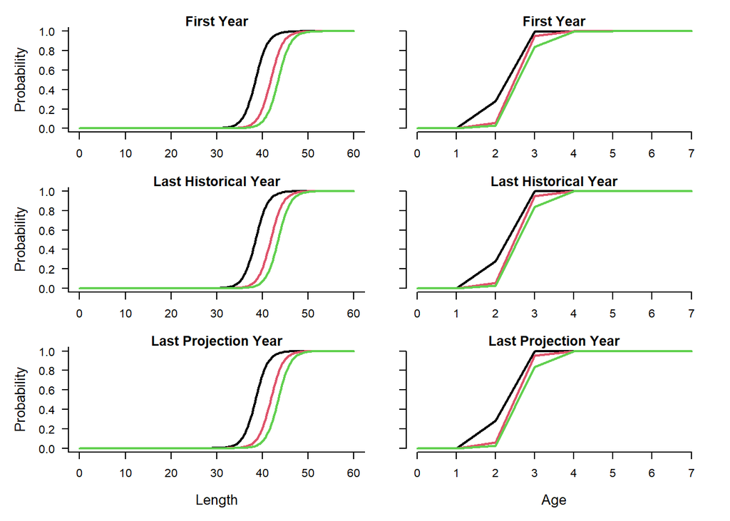

### Stock depletion and Discard Mortality: D, Fdisc

**D**: Estimated current level of stock depletion, which is defined as the current spawning stock biomass divided by the unfished spawning stock biomass. For each simulation a single value is drawn from a uniform distribution specified by the upper and lower bounds provided. This parameter is used during model initialization to select a series of yearly historical recruitment values and fishing mortality rates that, based on the information provided, could have resulted in the specified depletion level in the simulated last historical year. Uniform distribution lower and upper bounds. Positive real numbers (typically < 1)

Specified Value(s): 1, 3

Range of values indicating growing population, i.e. making SSB in the last historical year to be higher than SSB0. Given that we are imposing absence of fishing mortality in historical period via the parameters `EffLower` and `EffUpper`, values assigned to parameter `D` should be irrelevant in terms of depletion due to fishing. In this case, and for a given level of constant natural mortality, depletion level is simply reflecting changes in biomass due to variability in annual recruitment.

*Note 1*: Trial runs tested setting up an unexploited historical period via the `cpars` option, by providing a 0-filled matrix `cpars$Find`. `cpars$qs` values were also provided to skip the depletion optimization process. Unfortunately, and for no clear reason, MSE simulations crashed at the projection phase.

*Note 2*: Ideally it would be desirable to set the length of the historical period to zero, but that also does not seem possible under the current `{openMSE}` version. See more details in section Historical period above.

**Fdisc**: The instantaneous discard mortality rate the stock experiences when fished using the gear type specified in the corresponding fleet object and discarded. For each simulation a single value is drawn from a uniform distribution specified by the upper and lower bounds provided. Uniform distribution lower and upper bounds. Non-negative real numbers.

Specified Value(s): 0, 0

Arbitrary values, as discards are assumed non-existent, similarly to GRYM.

### Depletion and Discard Mortality

#### Sampled Parameters

Histograms of simulations of depletion (spawning biomass in the last historical year over average unfished spawning biomass; `D`) and the fraction of discarded fish that are killed by fishing mortality (`Fdisc`), with vertical colored lines indicating 3 randomly drawn values.

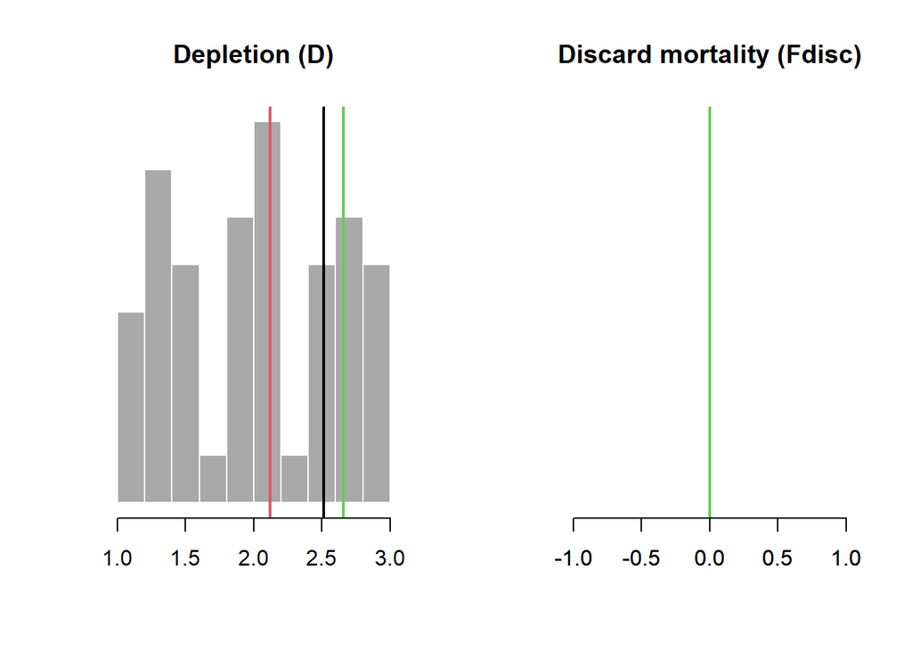

### Length-weight conversion parameters: a, b

**a**: The alpha parameter in allometric length-weight relationship. Single value. Weight parameters are used to determine catch-at-age and population-at-age from the number of individuals in each age class and the length of each individual, which is drawn from a normal distribution determined by the Linf , K , t0 , and LenCV parameters. As a result, they function as a way to scale between numbers at age and biomass, and are not stochastic parameters. Single value. Positive real number.

Specified Value(s): 0

Same estimate as that specified in Maschette et al. (2021) for the ‘initial’ weight-at-length relationship (via the power law, W = a * Lb). Note: units of weight and length are, respectively, grams and millimeters.

**b**: The beta parameter in allometric length-weight relationship. Single value. Weight parameters are used to determine catch-at-age and population-at-age from the number of individuals in each age class and the length of each individual, which is drawn from a normal distribution determine by the Linf , K , t0 , and LenCV parameters. As a result, they function as a way to scale between numbers at age and biomass, and are not stochastic parameters. Single value. Positive real number.

Specified Value(s): 3.31

Same estimate as that specified in Maschette et al. (2021) for the ‘initial’ weight-at-length relationship.

### Spatial distribution and movement: Size_area_1, Frac_area_1, Prob_staying

**Size_area_1**: The size of area 1 relative to area 2. The fraction of the unfished biomass in area 1. Please specify numbers between 0 and 1. For each simulation a single value is drawn from a uniform distribution specified by the upper and lower bounds provided. For example, if Size_area_1 is 0.2, then 20% of the total area is allocated to area 1. Fishing can occur in both areas, or can be turned off in one area to simulate the effects of a no take marine reserve. Uniform distribution lower and upper bounds. Positive real numbers.

Specified Value(s): 0.5, 0.5

Parameter value not allowed to be 1 (i.e. forcing one single area), so defining two sub-areas of equal size.

**Frac_area_1**: The fraction of the unfished biomass in area 1. Please specify numbers between 0 and 1. For each simulation a single value is drawn from a uniform distribution specified by the upper and lower bounds provided. For example, if Frac_area_1 is 0.5, then 50% of the unfished biomass is allocated to area 1, regardless of the size of area 1 (i.e, size and fraction in each area determine the density of fish, which may impact fishing spatial targeting). In each time step recruits are allocated to each area based on the proportion specified in Frac_area_1. Uniform distribution lower and upper bounds. Positive real numbers.

Specified Value(s): 0.5, 0.5

Parameter value not allowed to be 1 (i.e. forcing whole population in a single area), so specifying that population is evenly split between the two sub-areas.

**Prob_staying**: The probability of individuals in area 1 remaining in area 1 over the course of one year. Please specify numbers between 0 and 1. For each simulation a single value is drawn from a uniform distribution specified by the upper and lower bounds provided. For example, in an area with a Prob_staying value of 0.95 each fish has a 95% probability of staying in that area in each time step, and a 5% probability of moving to the other area. Uniform distribution lower and upper bounds. Positive fraction.

Specified Value(s): 0.5, 0.5

Assuming 50/50 chance of movement between sub-areas.

### Spatial & Movement

#### Sampled Parameters

Histograms of 48 simulations of size of area 1 (`Size_area_1`), fraction of unfished biomass in area 1 (`Frac_area_1`), and the probability of staying in area 1 in a year (`Frac_area_1`), with vertical colored lines indicating 3 randomly drawn values used in other plots:

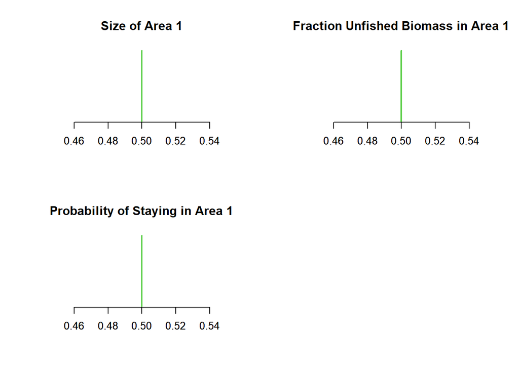

# Fleet Parameters

### Historical years of fishing, spatial targeting: nyears, Spat_targ

**nyears**: The number of years for the historical simulation. Single value. For example, if the simulated population is assumed to be unfished in 1975 and this is the year you want to start your historical simulations, and the most recent year for which there is data available is 2019, then nyears equals 45.

Specified Value(s): 5

Minimum allowed number of years for historical period. See more details in section Historical period above.

**Spat_targ**: Distribution of fishing in relation to vulnerable biomass (VB) across areas. The distribution of fishing effort is proportional to VB^Spat_targ. Upper and lower bounds of a uniform distribution. For each simulation a single value is drawn from a uniform distribution specified by the upper and lower bounds provided. This parameter allows the user to model either avoidance or spatial targeting behavior by the fleet. If the parameter value is 1, fishing effort is allocated across areas in proportion to the population density of that area. Values below 1 simulate an avoidance behavior and values above 1 simulate a targeting behavior.

Specified Value(s): 1, 1

Assuming effort is distributed in proportion to the population density.

### Trend in historical fishing effort (exploitation rate), interannual variability in fishing effort: EffYears, EffLower, EffUpper, Esd

**EffYears**: Vector indicating the historical years where there is information available to infer the relative fishing effort expended.This vector is specified in terms of the position of the year in the vector rather than the calendar year. For example, say our simulation starts with an unfished stock in 1975,and the current year (the last year for which there is data available) is 2019. Then there are 45 historical years simulated, and EffYears should include numbers between 1 and 45. Note that there may not be information available for every historical year, especially for data poor fisheries. In these situations, the EffYears vector should include only the positions of the years for which there is information, and the vector may be shorter than the total number of simulated historical years (nyears).

Arbitrary value - simulation requires at least one value to be provided, otherwise it crashes. Effort in the provided year will be null.

**EffLower**: Lower bound on relative fishing effort corresponding to EffYears. EffLower must be a vector that is the same length as EffYears describing how fishing effort has changed over time. Information on relative fishing effort can be entered in any units provided they are consistent across the entire vector because the data provided will be scaled to 1 (divided by the maximum number provided).

Population assumed to remain unexploited during the historical period.

**EffUpper**: Upper bound on relative fishing effort corresponding to EffYears. EffUpper must be a vector that is the same length as EffYears describing how fishing effort has changed over time. Information on relative fishing effort can be entered in any units provided they are consistent across the entire vector because the data provided will be scaled to 1 (divided by the maximum number provided).

Population assumed to remain unexploited during the historical period.

| EffYears | EffLower | EffUpper |
| --- | --- | --- |
| 2018 | 0 | 0 |

**Esd**: Additional inter-annual variability in fishing mortality rate. For each historical simulation a single value is drawn from a uniform distribution specified by the upper and lower bounds provided. If this parameter has a positive (non-zero) value, the yearly fishing mortality rate is drawn from a log-normal distribution with a standard deviation (in log space) specified by the value of Esd drawn for that simulation. This parameter applies only to historical projections.

Specified Value(s): 0, 0

Population assumed to remain unexploited during the historical period, so variability in historical fishing mortality is ignored.

### Historical Effort

#### Sampled Parameters

Histograms of 48 simulations of inter-annual variability in historical fishing mortality (`Esd`), with vertical colored lines indicating 3 randomly drawn values used in the time-series plot:

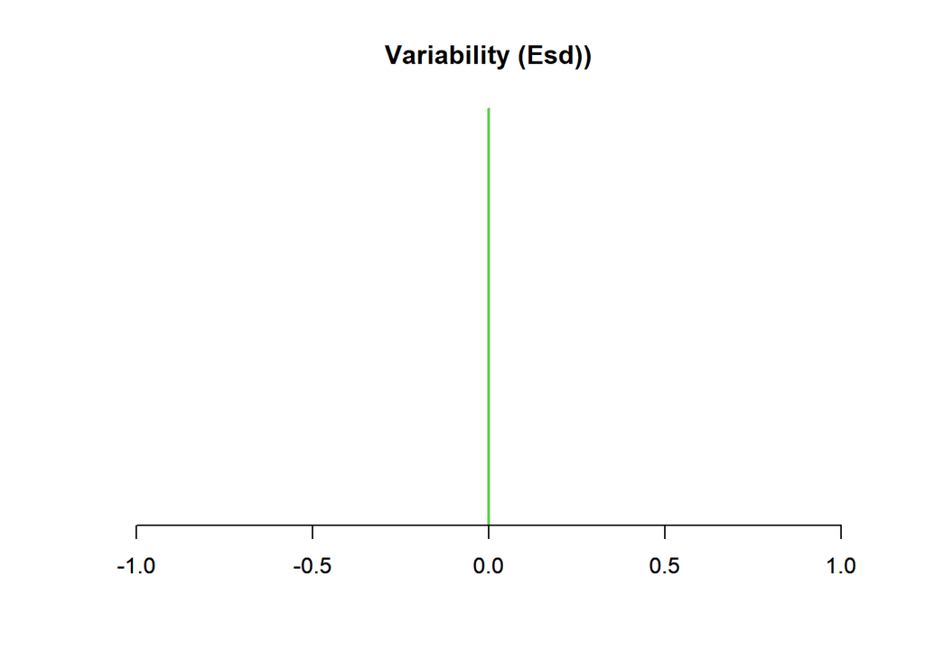

#### Time-Series

Time-series plot showing 3 trends in historical fishing mortality (`OM@EffUpper` and `OM@EffLower` or `OM@cpars$Find`):

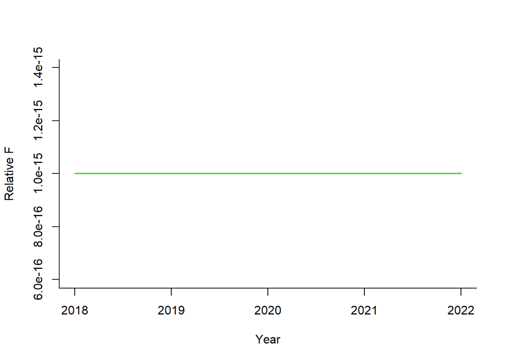

### Annual increase in catchability, interannual variability in catchability: qinc, qcv

**qinc**: Mean temporal trend in catchability (also though of as the efficiency of fishing gear) parameter, expressed as a percentage change in catchability (q) per year. For each simulation a single value is drawn from a uniform distribution specified by the upper and lower bounds provided. Positive numbers indicate an increase and negative numbers indicate a decrease. q then changes by this amount for in each year of the simulation This parameter applies only to forward projections.

Specified Value(s): 0, 0

Analogously to GRYM, assuming no change in gear efficiency over the projection years.

**qcv**: Inter-annual variability in catchability expressed as a coefficient of variation. For each simulation a single value is drawn from a uniform distribution specified by the upper and lower bounds provided. This parameter applies only to forward projections.

Specified Value(s): 0, 0

Analogously to GRYM, assuming constant gear catchability over the projection years.

### Future Catchability

#### Sampled Parameters

Histograms of 48 simulations of inter-annual variability in fishing efficiency (`qcv`) and average annual change in fishing efficiency (`qinc`), with vertical colored lines indicating 3 randomly drawn values used in the time-series plot:

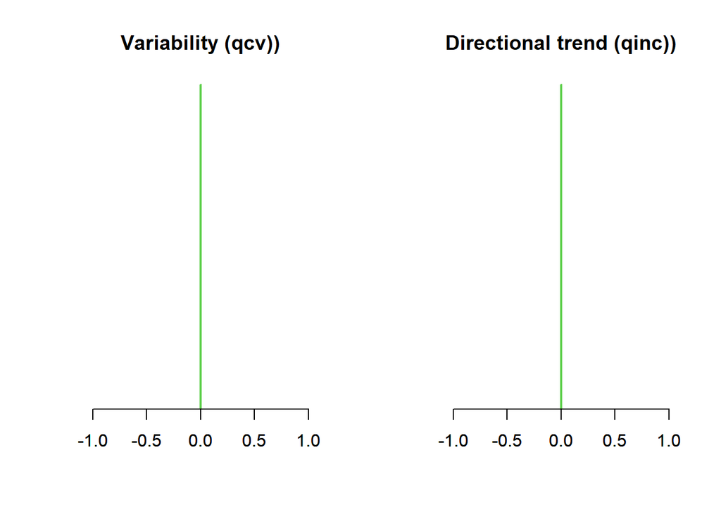

#### Time-Series

Time-series plot showing 3 trends in future fishing efficiency (catchability):

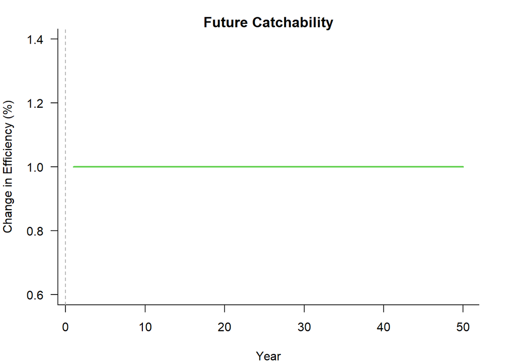

### Fishery gear length selectivity: L5, LFS, Vmaxlen, isRel

**L5**: Shortest length at which 5% of the population is vulnerable to selection by the gear used in this fleet. Values can either be specified as lengths (in the same units used for the maturity and growth parameters in the stock object) or as a percentage of the size of maturity (see the parameter isRel for more information). For each simulation a single value is drawn from a uniform distribution specified by the upper and lower bounds provided. This value is the same in all years unless cpars is used to provide time-varying selection.

Specified Value(s): 25.05, 30.05

Similarly to the maturity ogive, gear selectivity in `{GRYM}` is specified via a ramp function defined by two parameters: (i) `L50`, the length at which there is 50% retention probability for a given individual; and (ii) `SR`, the selection range.

Minimum and maximum values of `L50` and `SR` from Thanassekos et al (2021, *in* Maschette et al., 2021), which are used to derive min and max values of `L5` via the quantile function.

```r
SR <- 11
L50 <- c(30, 35)
L5 <- qunif(0.05, L50 - SR/2, L50 + SR/2)
L5
```

```
## [1] 25.05 30.05
```

**LFS**: Shortest length at which 100% of the population is vulnerable to selection by the gear used by this fleet. Values can either be specified as lengths (in the same units used for the maturity and growth parameters in the stock object) or as a percentage of the size of maturity (see the parameter isRel for more information). For each simulation a single value is drawn from a uniform distribution specified by the upper and lower bounds provided. This value is the same in all years unless cpars is used to provide time-varying selection.

Specified Value(s): 35.5, 40.5

Values derived from `L50` and `SR` from Thanassekos et al (2021), as above.

```r
L50 + SR/2
```

```
## [1] 35.5 40.5
```

**Vmaxlen**: Proportion of fish selected by the gear at the asymptotic length (‘Stock@Linf’). Upper and Lower bounds between 0 and 1. A value of 1 indicates that 100% of fish are selected at the asymptotic length, and the selection curve is logistic. If Vmaxlen is less than 1 the selection curve is dome shaped. For example, if Vmaxlen is 0.4, then only 40% of fish are vulnerable to the fishing gear at the asymptotic length.

Specified Value(s): 1, 1

All individuals considered to be selected at $L_{\infty}$, i.e. selectivity assumed to be logistic.

**isRel**: Specify whether selection and retention parameters use absolute lengths or relative to the size of maturity. Single logical value (TRUE or FALSE).

Specified Value(s): FALSE

Selectivity parameters are in absolute units.

### Fishery length retention: LR5, LFR, Rmaxlen, DR

**LR5**: Shortest length at which 5% of the population is vulnerable to retention by the fleet. Values can either be specified as lengths (in the same units used for the maturity and growth parameters in the stock object) or as a percentage of the size of maturity (see the parameter isRel for more information). For each simulation a single value is drawn from a uniform distribution specified by the upper and lower bounds provided. This value is the same in all years unless cpars is used to provide time-varying selection.

Specified Value(s): 0, 0

Analogously to GRYM, assuming no discards - i.e. all individuals selected by the gear are retained.

**LFR**: Shortest length where 100% of the population is vulnerable to retention by the fleet. Values can either be specified as lengths (in the same units used for the maturity and growth parameters in the stock object) or as a percentage of the size of maturity (see the parameter isRel for more information). For each simulation a single value is drawn from a uniform distribution specified by the upper and lower bounds provided. This value is the same in all years unless cpars is used to provide time-varying selection.

Specified Value(s): 0, 0

Analogously to GRYM, assuming no discards - i.e. all individuals selected by the gear are retained.

**Rmaxlen**: Proportion of fish retained at the asymptotic length (‘Stock@Linf’). Upper and Lower bounds between 0 and 1. A value of 1 indicates that 100% of fish are retained at the asymptotic length, and the selection curve is logistic. If Rmaxlen is less than 1 the retention curve is dome shaped. For example, if Rmaxlen is 0.4, then only 40% of fish at the asymptotic length are retained.

Specified Value(s): 1, 1

Same as `Vmaxlen`, i.e. 100% of fish are retained at $L_{\infty}$.

**DR**: Discard rate, defined as the proportion of fully selected fish that are discarded by the fleet. Upper and Lower bounds between 0 and 1, with a value of 1 indicates that 100% of selected fish are discarded. For each simulation a single value is drawn from a uniform distribution specified by the upper and lower bounds provided.

Specified Value(s): 0, 0

Assuming no discards.

### Current Year: CurrentYr

**CurrentYr**: The last historical year simulated before projections begin. Single value. Note that this should match the last historical year specified in the Data object, which is usually the last historical year for which data is available.

Specified Value(s): 2022

Final year with available data.

### Existing Spatial Closures: MPA

**MPA**: Logical argument (TRUE or FALSE). Creates an MPA in Area 1 for all years if true is selected. Defaults to FALSE.

Specified Value(s): FALSE

Stock assumed to be constrained to one single area.

# Obs Parameters

This section is mostly irrelevant for this comparison with GRYM, as specifiedMPs (one for each level of harvest rate ‘gamma’) don’t require observed/sampleddata from the fishery.

### Catch statistics: Cobs, Cbiascv, CAA_nsamp, CAA_ESS, CAL_nsamp, CAL_ESS

**Cobs**: Observation error around the total catch. Observation error in the total catch is expressed as a coefficient of variation (CV). Cobs requires upper and lower bounds of a uniform distribution, and for each simulation a CV is sampled from this distribution. Each CV is used to specify a log-normal error distribution with a mean of 1 and a standard deviation equal to the sampled CV. The yearly observation error values for the catch data are then drawn from this distribution. For each time step the simulation model records the true catch, but the observed catch is generated by applying this yearly error term (plus any bias, if specified) to the true catch.

Specified Value(s): 0, 0

Catch assumed known without observation error.

**Cbiascv**: Log-normally distributed coefficient of variation controlling the sampling bias in observed catch for each simulation. Bias occurs when catches are systematically skewed away from the true catch level (for example, due to underreporting of catch or undetected illegal catches). Cbiascv is a single value specifying the standard deviation of a log-normal distribution with a mean of 1 and a standard deviation equal to the sampled CV. For each simulation a bias value is drawn from this distribution, and that bias is applied across all years.

Specified Value(s): 0

Catch assumed known without observation bias.

**CAA_nsamp**: Number of catch-at-age observations collected per time step. For each time step a single value is drawn from a uniform distribution specified by the upper and lower bounds provided. Positive integers.

Specified Value(s): 0, 0

No catch-at-age sampling.

**CAA_ESS**: Effective sample size of catch-at-age observations collected per time step. For each time step a single value is drawn from a uniform distribution specified by the upper and lower bounds provided. CAA_ESS should not exceed CAA_nsamp. If greater than 1, then this is the multinomial distribution sample size. If less than 1, this is the coefficient of variation for the logistic normal distribution (see help doucmentation for simCAA for details).

Specified Value(s): 0, 0

No catch-at-age sampling.

**CAL_nsamp**: Number of catch-at-length observations collected per time step. For each time step a single value is drawn from a uniform distribution specified by the upper and lower bounds provided. Positive integers.

Specified Value(s): 0, 0

No catch-at-length sampling.

**CAL_ESS**: Effective sample size. For each time step a single value is drawn from a uniform distribution specified by the upper and lower bounds provided. CAL_ESS should not exceed CAL_nsamp. Positive integers.

Specified Value(s): 0, 0

No catch-at-length sampling.

### Index imprecision, bias and hyperstability: Iobs, Btobs, Btbiascv, beta

**Iobs**: Observation error in the relative abundance index expressed as a coefficient of variation (CV). Iobs requires upper and lower bounds of a uniform distribution, and for each simulation a CV is sampled from this distribution. Each CV is used to specify a log-normal error distribution with a mean of 1 and a standard deviation equal to the sampled CV. The yearly observation error values for the index of abundance data are then drawn from this distribution. For each time step the simulation model records the true change in abundance, but the observed index is generated by applying this yearly error term (plus any bias, if specified) to the true relative change in abundance. Positive real numbers.

Specified Value(s): 0, 0

No observation error in the relative abundance index.

**Btobs**: Observation error in the absolute abundance expressed as a coefficient of variation (CV). Btobs requires upper and lower bounds of a uniform distribution, and for each simulation a CV is sampled from this distribution. Each CV is used to specify a log-normal error distribution with a mean of 1 and a standard deviation equal to the sampled CV. The yearly observation error values for the absolute abundance data are then drawn from this distribution. For each time step the simulation model records the true abundance, but the observed abundance is generated by applying this yearly error term (plus any bias, if specified) to the true abundance. Positive real numbers.

Specified Value(s): 0, 0

No observation error in the absolute abundance index.

**Btbiascv**: Log-normally distributed coefficient (CV) controlling error in observations of the current stock biomass. Bias occurs when the observed index of abundance is is systematically higher or lower than the true relative abundance. Btbiascv is a single value specifying the standard deviation of a log-normal distribution with a mean of 1 and a standard deviation equal to the sampled CV. For each simulation a bias value is drawn from this distribution, and that bias is applied across all years. Positive real numbers.

Specified Value(s): 0

No bias in observations of stock biomass.

**beta**: A parameter controlling hyperstability/hyperdepletion in the measurement of abundance. For each simulation a single value is drawn from a uniform distribution specified by the upper and lower bounds provided. Values below 1 lead to hyperstability (the observed index decreases more slowly than the true abundance) and values above 1 lead to hyperdepletion (the observed index decreases more rapidly than true abundance). Positive real numbers.

Specified Value(s): 0, 0

### Bias in maturity, natural mortality rate and growth parameters: LenMbiascv, Mbiascv, Kbiascv,t0biascv, Linfbiascv

**LenMbiascv**: Log-normal coefficient of variation for sampling bias in observed length at 50 percent maturity. LenMbiascv is a single value specifying the standard deviation of a log-normal distribution with a mean of 1 and a standard deviation equal to the sampled CV. For each simulation a bias value is drawn from this distribution, and that bias is applied across all years. Positive real numbers.

Specified Value(s): 0

Assuming no bias in estimated biological parameters.

**Mbiascv**: Log-normal coefficient of variation for sampling bias in observed natural mortality rate. Mbiascv is a single value specifying the standard deviation of a log-normal distribution with a mean of 1 and a standard deviation equal to the sampled CV. For each simulation a bias value is drawn from this distribution, and that bias is applied across all years. Positive real numbers.

Specified Value(s): 0

Assuming no bias in estimated biological parameters.

**Kbiascv**: Log-normal coefficient of variation for sampling bias in observed growth parameter K. Kbiascv is a single value specifying the standard deviation of a log-normal distribution with a mean of 1 and a standard deviation equal to the sampled CV. For each simulation a bias value is drawn from this distribution, and that bias is applied across all years. Positive real numbers.

Specified Value(s): 0

Assuming no bias in estimated biological parameters.

**t0biascv**: Log-normal coefficient of variation for sampling bias in observed t0. t0biascv is a single value specifying the standard deviation of a log-normal distribution with a mean of 1 and a standard deviation equal to the sampled CV. For each simulation a bias value is drawn from this distribution, and that bias is applied across all years. Positive real numbers.

Specified Value(s): 0

Assuming no bias in estimated biological parameters.

**Linfbiascv**: Log-normal coefficient of variation for sampling bias in observed maximum length. Linfbiascv is a single value specifying the standard deviation of a log-normal distribution with a mean of 1 and a standard deviation equal to the sampled CV. For each simulation a bias value is drawn from this distribution, and that bias is applied across all years. Positive real numbers.

Specified Value(s): 0

Assuming no bias in estimated biological parameters.

### Bias in length at first capture, length at full selection: LFCbiascv, LFSbiascv

**LFCbiascv**: Log-normal coefficient of variation for sampling bias in observed length at first capture. LFCbiascv is a single value specifying the standard deviation of a log-normal distribution with a mean of 1 and a standard deviation equal to the sampled CV. For each simulation a bias value is drawn from this distribution, and that bias is applied across all years. Positive real numbers.

Specified Value(s): 0

Assuming no bias in estimated biological parameters.

**LFSbiascv**: Log-normal coefficient of variation for sampling bias in length-at-full selection. LFSbiascv is a single value specifying the standard deviation of a log-normal distribution with a mean of 1 and a standard deviation equal to the sampled CV. For each simulation a bias value is drawn from this distribution, and that bias is applied across all years. Positive real numbers.

Specified Value(s): 0

Assuming no bias in estimated biological parameters.

### Bias in fishery reference points, unfished biomass, FMSY, FMSY/M ratio, biomass at MSY relative to unfished: FMSY_Mbiascv, BMSY_B0biascv

**FMSY_Mbiascv**: Log-normal coefficient of variation for sampling bias in estimates of the ratio of the fishing mortality rate that gives the maximum sustainable yield relative to the assumed instantaneous natural mortality rate. FMSY/M. FMSY_Mbiascv is a single value specifying the standard deviation of a log-normal distribution with a mean of 1 and a standard deviation equal to the sampled CV. For each simulation a bias value is drawn from this distribution, and that bias is applied across all years. Positive real numbers.

Specified Value(s): 0

Assuming no bias.

**BMSY_B0biascv**: Log-normal coefficient of variation for sampling bias in estimates of the BMSY relative to unfished biomass (BMSY/B0). BMSY_B0biascv is a single value specifying the standard deviation of a log-normal distribution with a mean of 1 and a standard deviation equal to the sampled CV. For each simulation a bias value is drawn from this distribution, and that bias is applied across all years. Positive real numbers.

Specified Value(s): 0

Assuming no bias.

### Management targets in terms of the index (i.e., model free), the total annual catches and absolute biomass levels: Irefbiascv, Crefbiascv, Brefbiascv

**Irefbiascv**: Log-normal coefficient of variation for sampling bias in the observed relative index of abundance (Iref). Irefbiascv is a single value specifying the standard deviation of a log-normal distribution with a mean of 1 and a standard deviation equal to the sampled CV. For each simulation a bias value is drawn from this distribution, and that bias is applied across all years. Positive real numbers.

Specified Value(s): 0

Assuming no bias.

**Crefbiascv**: Log-normal coefficient of variation for sampling bias in the observed reference catch (Cref). Crefbiascv is a single value specifying the standard deviation of a log-normal distribution with a mean of 1 and a standard deviation equal to the sampled CV. For each simulation a bias value is drawn from this distribution, and that bias is applied across all years. Positive real numbers.

Specified Value(s): 0

Assuming no bias.

**Brefbiascv**: Log-normal coefficient of variation for sampling bias in the observed reference biomass (Bref). Brefbiascv is a single value specifying the standard deviation of a log-normal distribution with a mean of 1 and a standard deviation equal to the sampled CV. For each simulation a bias value is drawn from this distribution, and that bias is applied across all years. Positive real numbers.

Specified Value(s): 0

Assuming no bias.

### Depletion bias and imprecision: Dbiascv, Dobs

**Dbiascv**: Log-normal coefficient of variation for sampling bias in the observed depletion level. Dbiascv is a single value specifying the standard deviation of a log-normal distribution with a mean of 1 and a standard deviation equal to the sampled CV. For each simulation a bias value is drawn from this distribution, and that bias is applied across all years. Positive real numbers.

Specified Value(s): 0

Assuming no bias.

**Dobs**: Log-normal coefficient of variation controlling error in observations of stock depletion among years. Observation error in the depletion expressed as a coefficient of variation (CV). Dobs requires the upper and lower bounds of a uniform distribution, and for each simulation a CV is sampled from this distribution. Each CV is used to specify a log-normal error distribution with a mean of 1 and a standard deviation equal to the sampled CV. The yearly observation error values for the depletion data are then drawn from this distribution. For each time step the simulation model records the true depletion, but the observed depletion is generated by applying this yearly error term (plus any bias, if specified) to the true depletion.

Specified Value(s): 0, 0

Assuming no bias.

### Recruitment compensation and trend: hbiascv, Recbiascv, sigmaRbiascv

**hbiascv**: Log-normal coefficient of variation for sampling persistent bias in steepness. hbiascv is a single value specifying the standard deviation of a log-normal distribution with a mean of 1 and a standard deviation equal to the sampled CV. For each simulation a bias value is drawn from this distribution, and that bias is applied across all years. Positive real numbers.

Specified Value(s): 0

Assuming no bias.

**Recbiascv**: Log-normal coefficient of variation for sampling persistent bias in recent recruitment strength. Recbiascv requires the upper and lower bounds of a uniform distribution, and for each simulation a CV is sampled from this distribution. Each CV is used to specify a log-normal error distribution with a mean of 1 and a standard deviation equal to the sampled CV. The yearly bias values for the depletion data are then drawn from this distribution. Positive real numbers.

Specified Value(s): 0, 0

Assuming no bias.

**sigmaRbiascv**: Log-normal coefficient of variation for sampling persistent bias in recruitment variability. sigmaRbiascv is a single value specifying the standard deviation of a log-normal distribution with a mean of 1 and a standard deviation equal to the sampled CV. For each simulation a bias value is drawn from this distribution, and that bias is applied across all years. Positive real numbers.

Specified Value(s): 0

Assuming no bias.

### Effort: Eobs, Ebiascv

**Eobs**: Observation error around the total effort. Observation error in the total effort is expressed as a coefficient of variation (CV). Eobs requires upper and lower bounds of a uniform distribution, and for each simulation a CV is sampled from this distribution. Each CV is used to specify a log-normal error distribution with a mean of 1 and a standard deviation equal to the sampled CV. The yearly observation error values for the effort data are then drawn from this distribution. For each time step the simulation model records the true effort, but the observed effort is generated by applying this yearly error term (plus any bias, if specified) to the true effort.

Specified Value(s): 0, 0

No observation error around the total effort

**Ebiascv**: Log-normally distributed coefficient of variation controlling the sampling bias in observed effort for each simulation. Bias occurs when effort is systematically skewed away from the true effort level. Ebiascv is a single value specifying the standard deviation of a log-normal distribution with a mean of 1 and a standard deviation equal to the sampled CV. For each simulation a bias value is drawn from this distribution, and that bias is applied across all years.

Specified Value(s): 0

Assuming no bias.

## Observation Parameters

### Catch Observations

#### Sampled Parameters

Histograms of 48 simulations of inter-annual variability in catch observations (`Csd`) and persistent bias in observed catch (`Cbias`), with vertical colored lines indicating 3 randomly drawn values used in other plots:

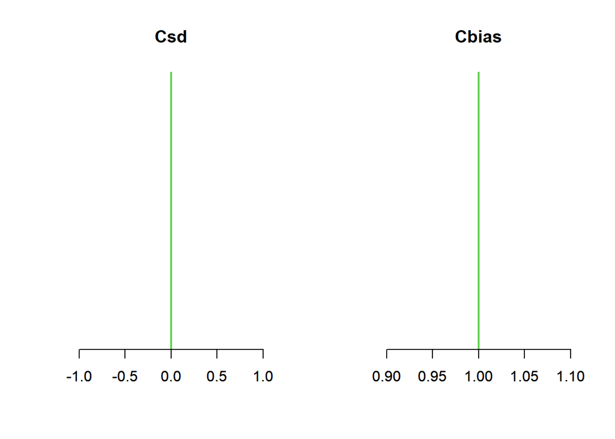

#### Time-Series

Time-series plots of catch observation error for historical and projection years:

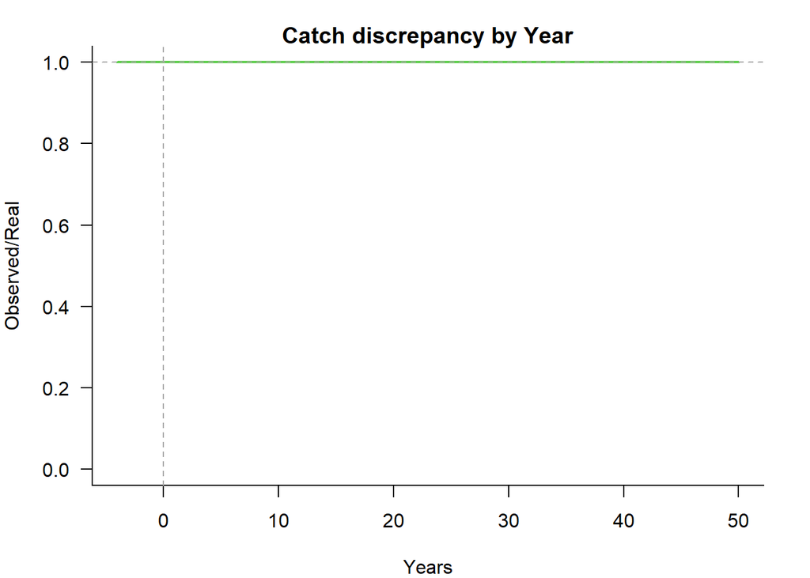

### Depletion Observations

#### Sampled Parameters

Histograms of 48 simulations of inter-annual variability in depletion observations (`Dobs`) and persistent bias in observed depletion (`Dbias`), with vertical colored lines indicating 3 randomly drawn values used in other plots:

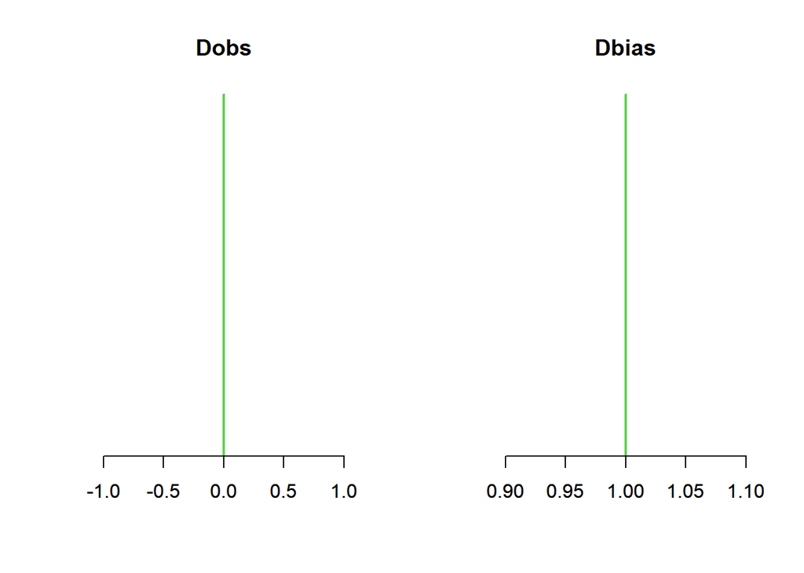

#### Time-Series

Time-series plots of depletion observation error for historical and projection years:

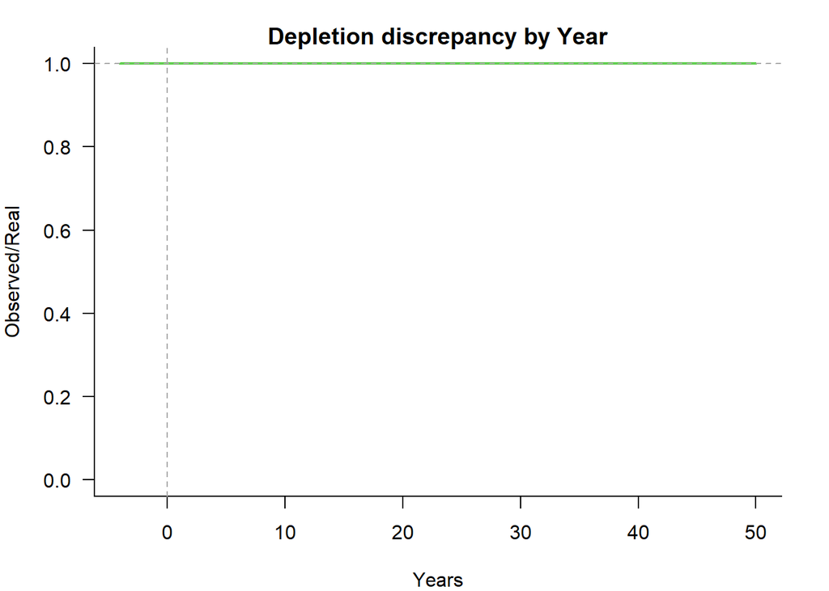

### Abundance Observations

#### Sampled Parameters

Histograms of 48 simulations of inter-annual variability in abundance observations (`Btobs`) and persistent bias in observed abundance (`Btbias`), with vertical colored lines indicating 3 randomly drawn values used in other plots:

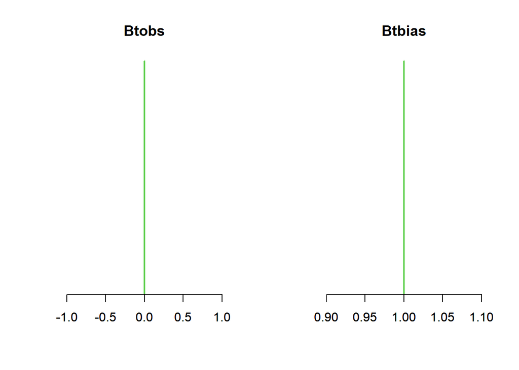

#### Time-Series

Time-series plots of abundance observation error for historical and projection years:

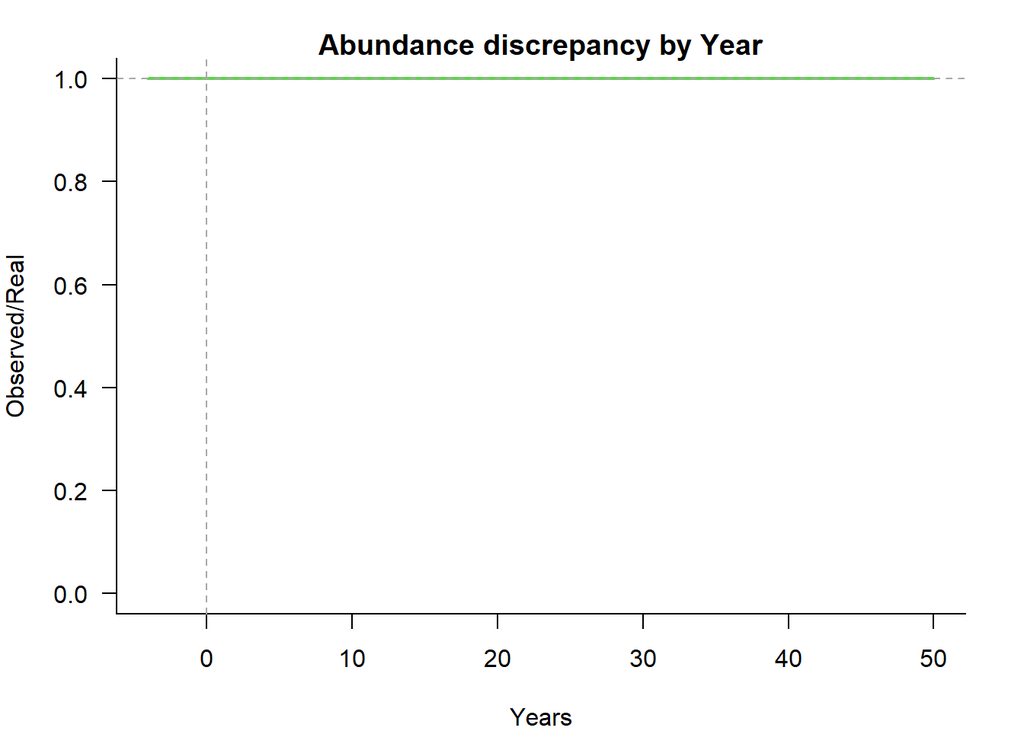

### Index Observations

#### Sampled Parameters

Histograms of 48 simulations of inter-annual variability in index observations (`Iobs`) and hyper-stability/depletion in observed index (`beta`), with vertical colored lines indicating 3 randomly drawn values used in other plots:

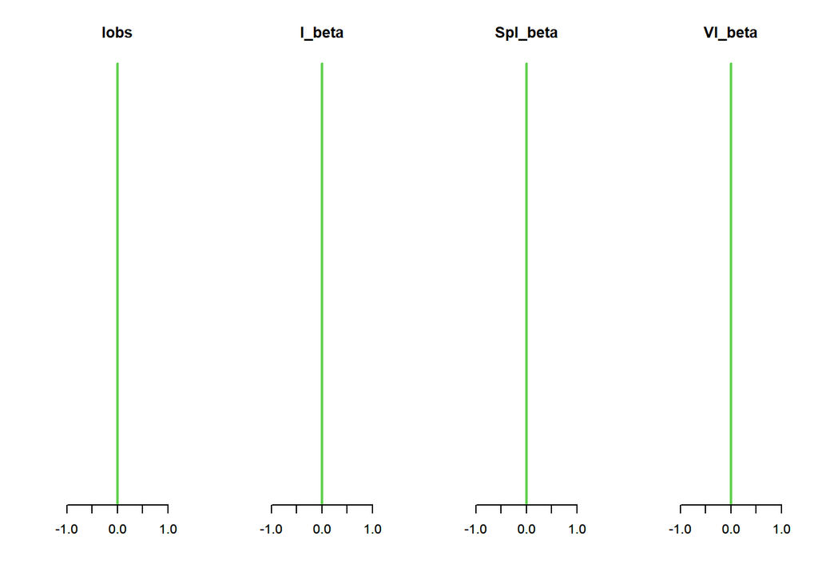

#### Time-Series

Time-series plot of 3 samples of index observation error:

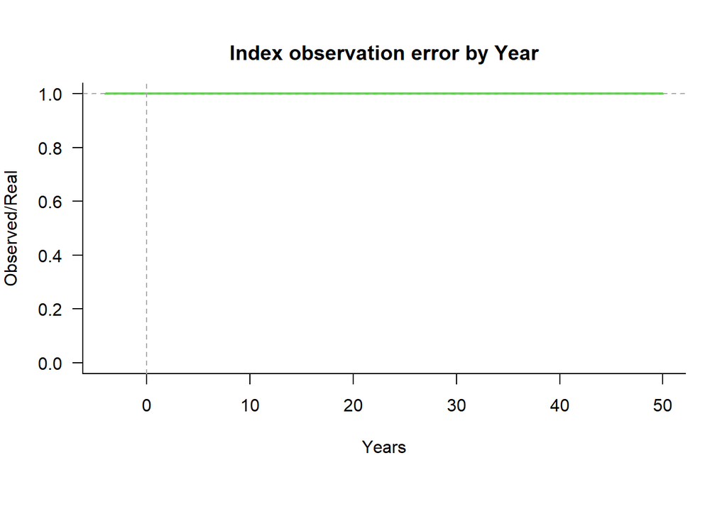

Plot showing an example true abundance index (blue) with 3 samples of index observation error and the hyper-stability/depletion parameter (`beta`):

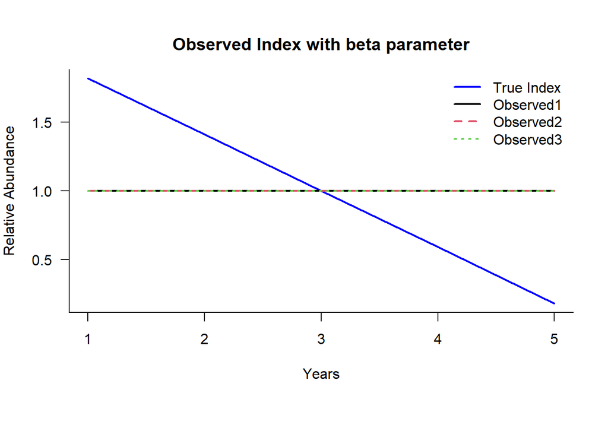

### Recruitment Observations

#### Sampled Parameters

Histograms of 48 simulations of inter-annual variability in index observations (`Recsd`) , with vertical colored lines indicating 3 randomly drawn values used in other plots:

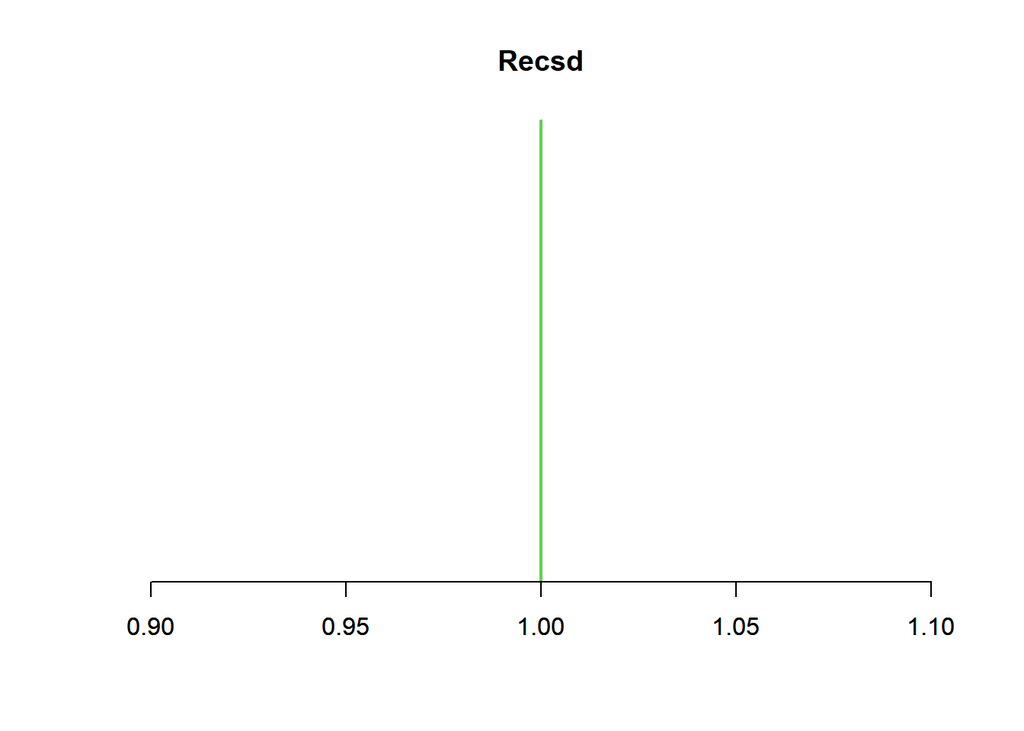

#### Time-Series

Timeseries plots of observeration error for recruitment:

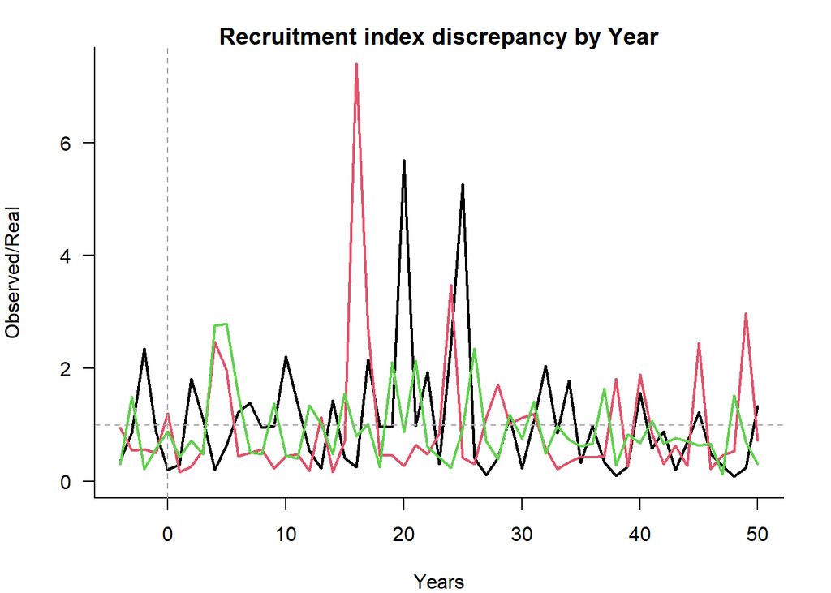

### Composition Observations

#### Sampled Parameters

Histograms of 48 simulations of catch-at-age effective sample size (`CAA_ESS`) and sample size (`CAA_nsamp`) and catch-at-length effective (`CAL_ESS`) and actual sample size (`CAL_nsamp`) with vertical colored lines indicating 3 randomly drawn values:

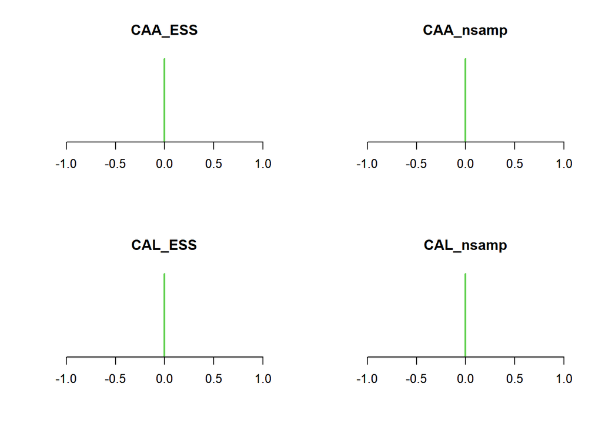

### Parameter Observations

#### Sampled Parameters

Histograms of 48 simulations of bias in observed natural mortality (`Mbias`), von Bertalanffy growth function parameters (`Linfbias`, `Kbias`, and `t0bias`), length-at-maturity (`lenMbias`), and bias in observed length at first capture (`LFCbias`) and first length at full capture (`LFSbias`) with vertical colored lines indicating 3 randomly drawn values:

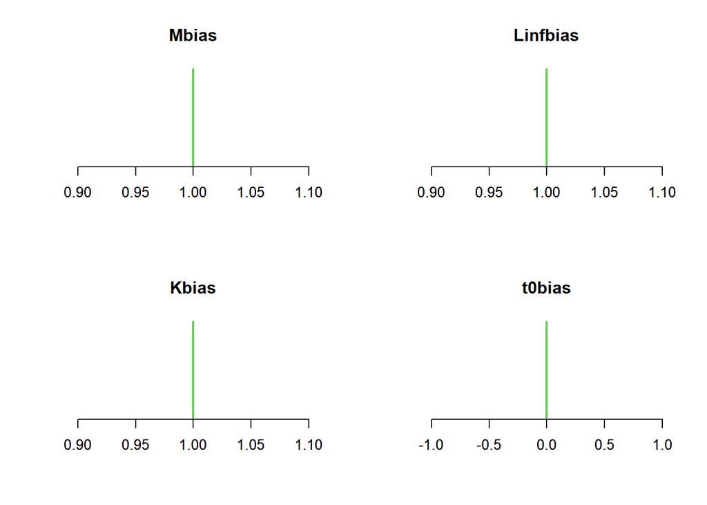

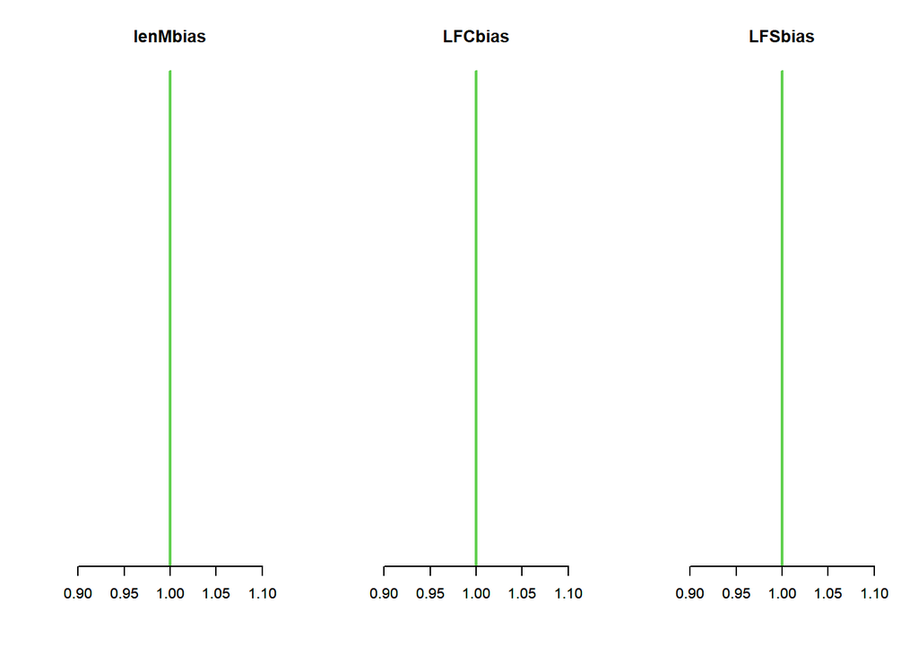

### Reference Point Observations

#### Sampled Parameters

Histograms of 48 simulations of bias in observed FMSY/M (`FMSY_Mbias`), BMSY/B0 (`BMSY_B0bias`), reference index (`Irefbias`), reference abundance (`Brefbias`) and reference catch (`Crefbias`), with vertical colored lines indicating 3 randomly drawn values:

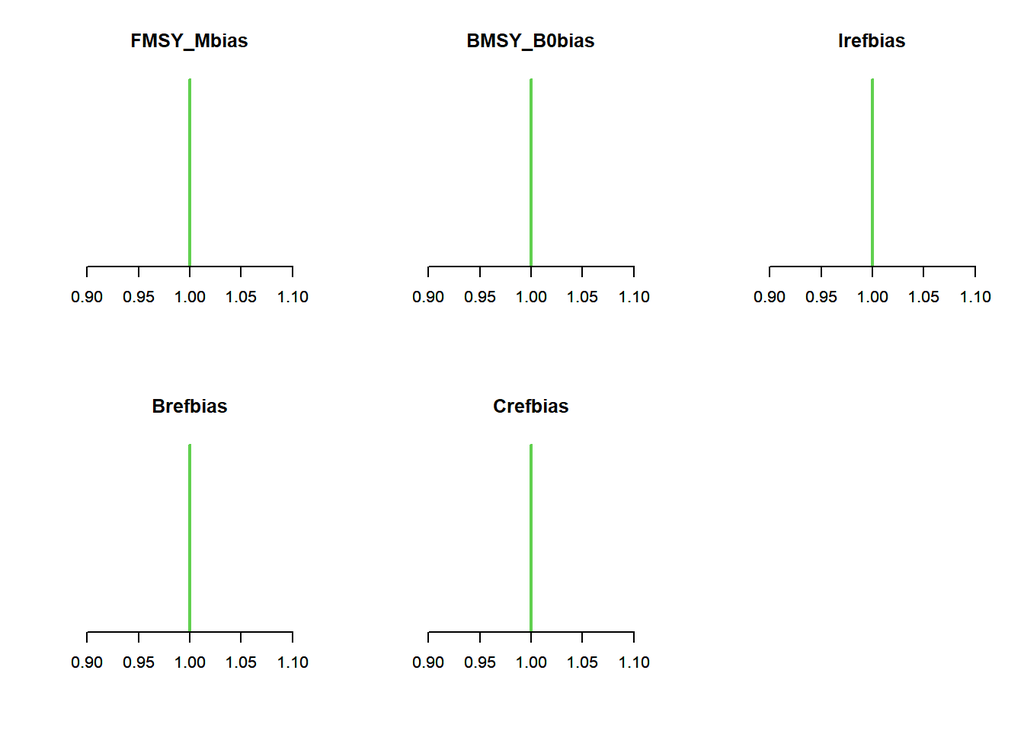

# Imp Parameters

### Output Control Implementation Error: TACFrac, TACSD

**TACFrac**: Mean fraction of recommended TAC that is actually taken. For each historical simulation a single value is drawn from a uniform distribution specified by the upper and lower bounds provided. This value is the mean TAC fraction obtained across all years of that simulation, and a yearly TAC frac is drawn from a log-normal distribution with the simulation mean and a coefficient of variation specified by the value of TACSD drawn for that simulation. If the value drawn is greater than 1 the amount of catch taken is greater than that recommended by the TAC, and if it is less than 1 the amount of catch taken is less than that recommended by the TAC. Positive real numbers.

Specified Value(s): 1, 1

Borrowed from: Perfect_Imp

**TACSD**: Log-normal coefficient of variation in the fraction of recommended TAC that is actually taken. For each historical simulation a single value is drawn from a uniform distribution specified by the upper and lower bounds provided. This value is used, along with the TACFrac drawn for that simulation, to create a log-normal distribution that yearly values specifying the actual amount of catch taken are drawn from. Positive real numbers.

Specified Value(s): 0, 0

Borrowed from: Perfect_Imp

### Effort Control Implementation Error: TAEFrac, TAESD

**TAEFrac**: Mean fraction of recommended TAE that is actually taken. For each historical simulation a single value is drawn from a uniform distribution specified by the upper and lower bounds provided. This value is the mean TAE fraction obtained across all years of that simulation, and a yearly TAE frac is drawn from a log-normal distribution with the simulation mean and a coefficient of variation specified by the value of TAESD drawn for that simulation. If the value drawn is greater than 1 the amount of effort employed is greater than that recommended by the TAE, and if it is less than 1 the amount of effort employed is less than that recommended by the TAE. Positive real numbers.

Specified Value(s): 1, 1

Borrowed from: Perfect_Imp

**TAESD**: Log-normal coefficient of variation in the fraction of recommended TAE that is actually taken. For each historical simulation a single value is drawn from a uniform distribution specified by the upper and lower bounds provided. This value is used, along with the TAEFrac drawn for that simulation, to create a log-normal distribution that yearly values speciying the actual amount of efort employed are drawn from. Positive real numbers.

Specified Value(s): 0, 0

Borrowed from: Perfect_Imp

### Size Limit Control Implementation Error: SizeLimFrac, SizeLimSD

**SizeLimFrac**: Mean fraction of recommended size limit that is actually retained. For each historical simulation a single value is drawn from a uniform distribution specified by the upper and lower bounds provided. This value is the mean size limit fraction obtained across all years of that simulation, and a yearly size limit fraction is drawn from a log-normal distribution with the simulation mean and a coefficient of variation specified by the value of SizeLimSD drawn for that simulation. If the value drawn is greater than 1 the size of fish retained is greater than that recommended by the size limit, and if it is less than 1 the amount of size of fish retained is less than that recommended by the size limit. Positive real numbers.

Specified Value(s): 1, 1

Borrowed from: Perfect_Imp

**SizeLimSD**: Log-normal coefficient of variation in the fraction of recommended size limit that is actually retained. For each historical simulation a single value is drawn from a uniform distribution specified by the upper and lower bounds provided. This value is used, along with the SizeLimFrac drawn for that simulation, to create a log-normal distribution that yearly values speciying the actual fraction of the size limit retained are drawn from. Positive real numbers.

Specified Value(s): 0, 0

Borrowed from: Perfect_Imp

## Implementation Parameters

### TAC Implementation

#### Sampled Parameters

Histograms of 0 simulations of inter-annual variability in TAC implementation error (`TACSD`) and persistent bias in TAC implementation (`TACFrac`), with vertical colored lines indicating 3 randomly drawn values used in other plots:

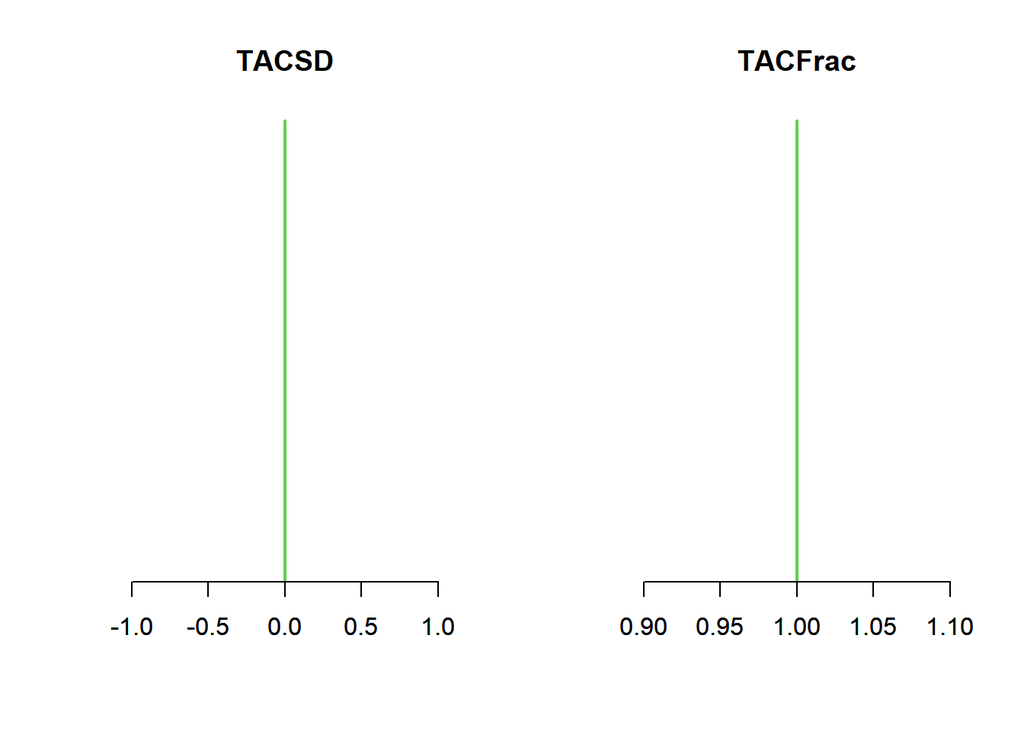

#### Time-Series

Time-series plots of 0 samples of TAC implementation error by year:

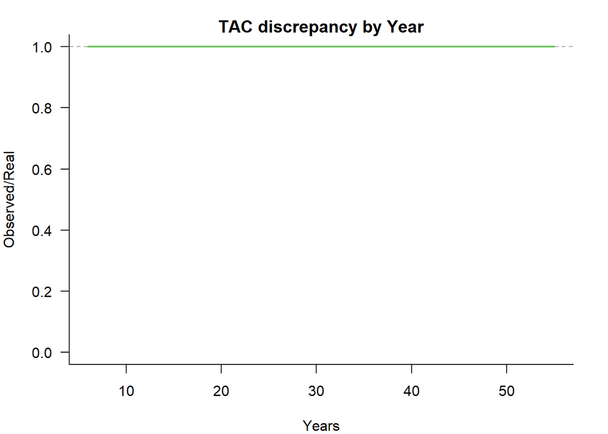

### TAE Implementation

#### Sampled Parameters

Histograms of 0 simulations of inter-annual variability in TAE implementation error (`TAESD`) and persistent bias in TAC implementation (`TAEFrac`), with vertical colored lines indicating 3 randomly drawn values used in other plots:

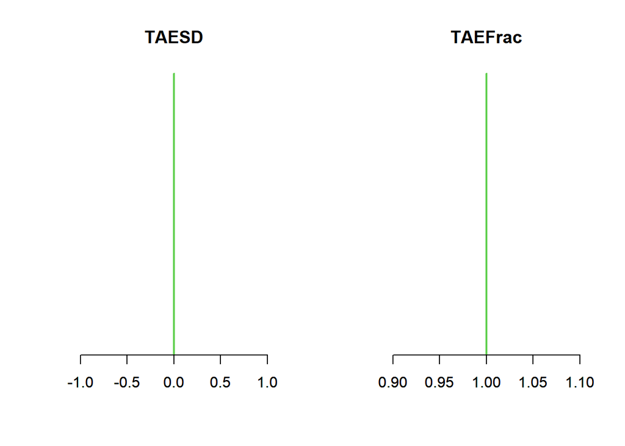

#### Time-Series

Time-series plots of 0 samples of TAE implementation error by year:

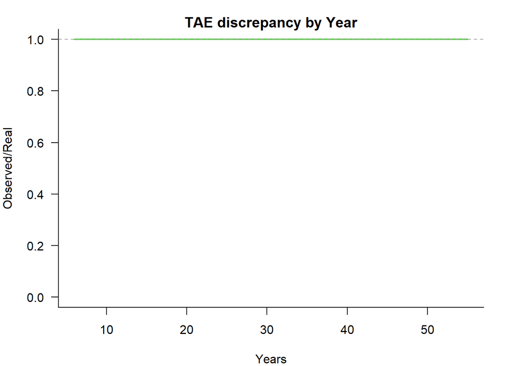

### Size Limit Implementation

#### Sampled Parameters

Histograms of 0 simulations of inter-annual variability in size limit implementation error (`SizeLimSD`) and persistent bias in size limit implementation (`SizeLimFrac`), with vertical colored lines indicating 3 randomly drawn values used in other plots:

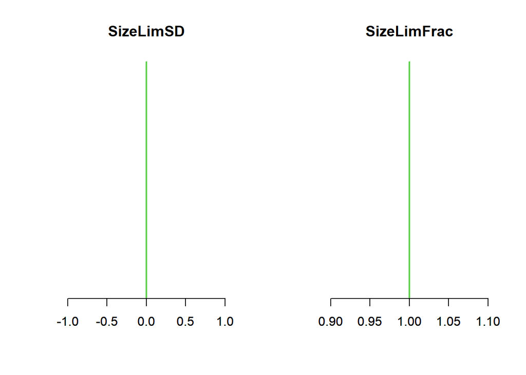

#### Time-Series

Time-series plots of 0 samples of Size Limit implementation error by year:

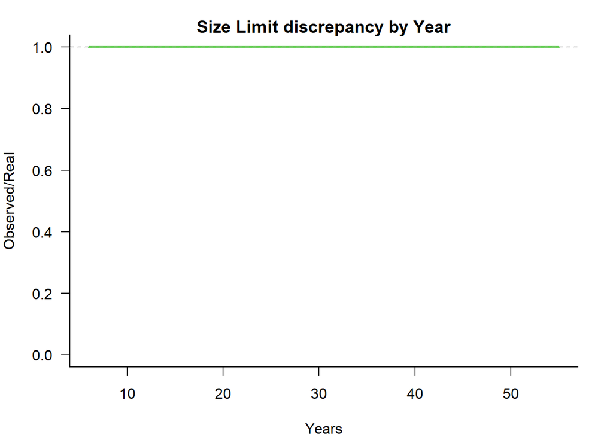

# Historical Simulation Plots

## Historical Time-Series

### Spawning Biomass

#### Depletion

Time-series plots of SB/SB0:

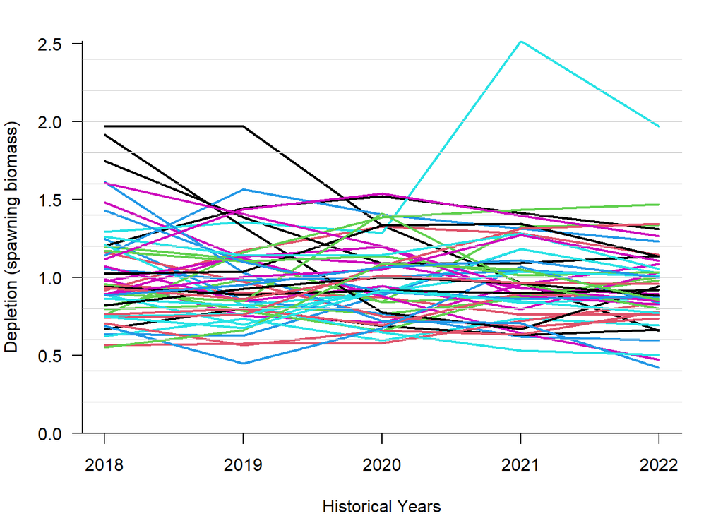

#### Absolute

Time-series plots of absolute SB:

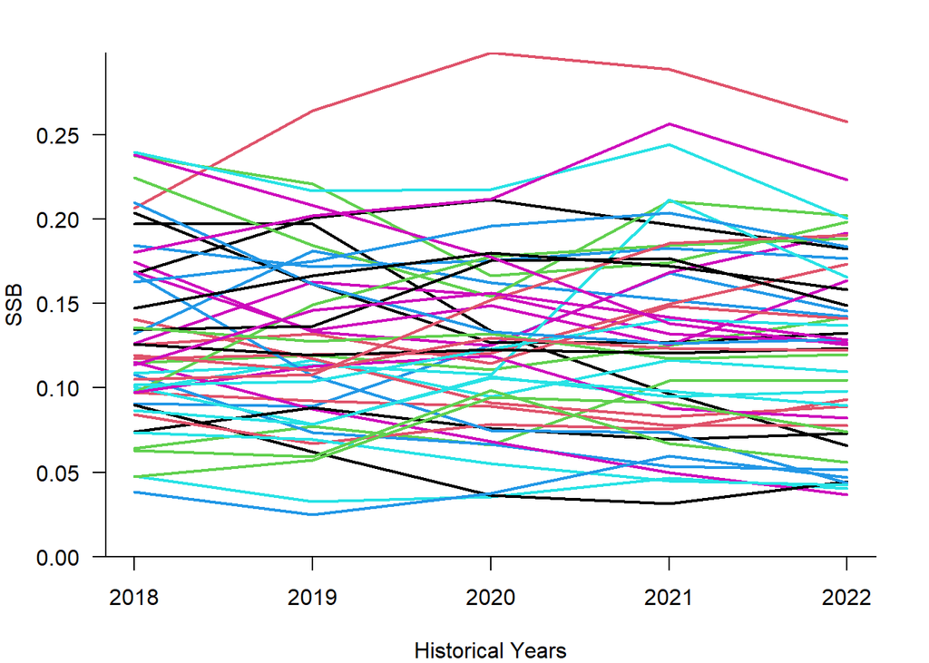

### Vulnerable Biomass

#### Depletion

Time-series plots of VB/VB0:

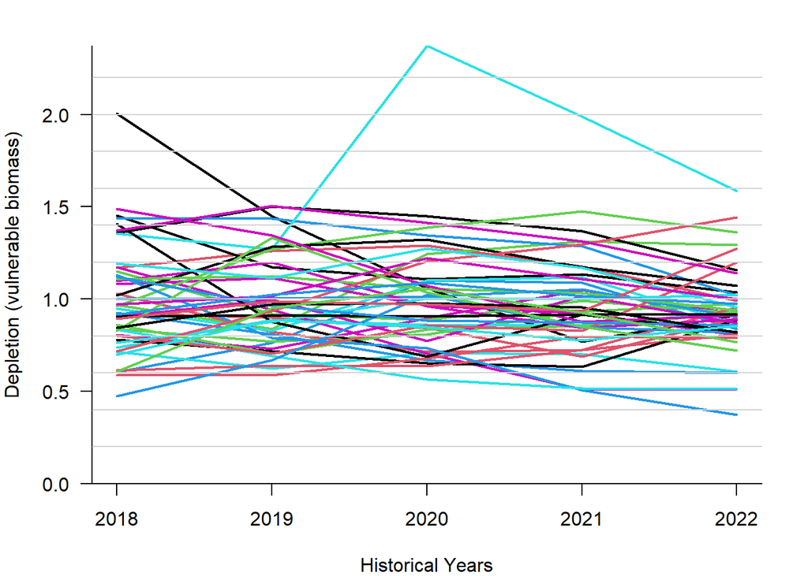

#### Absolute

Time-series plots of absolute VB:

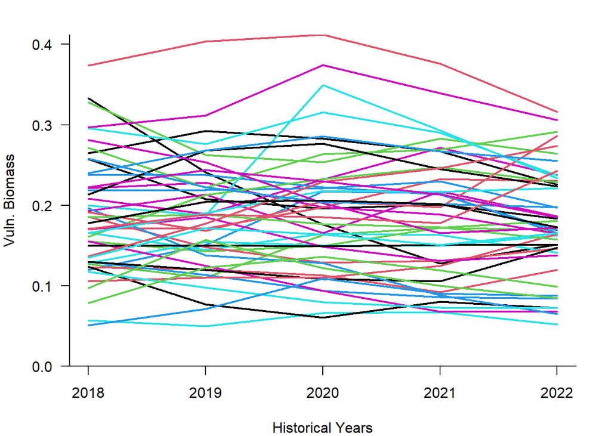

### Total Biomass

#### Depletion

Time-series plots of B/B0:

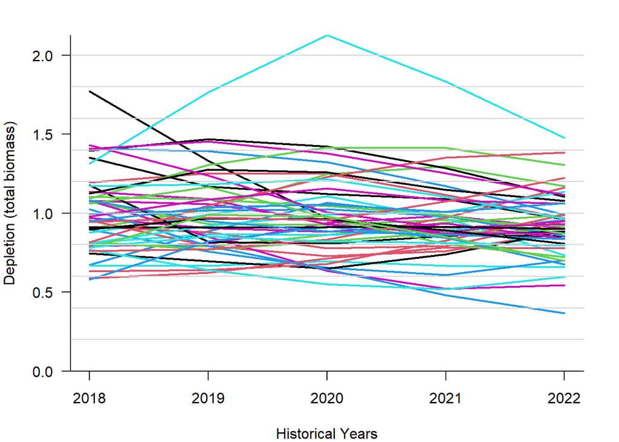

#### Absolute

Time-series plots of absolute B:

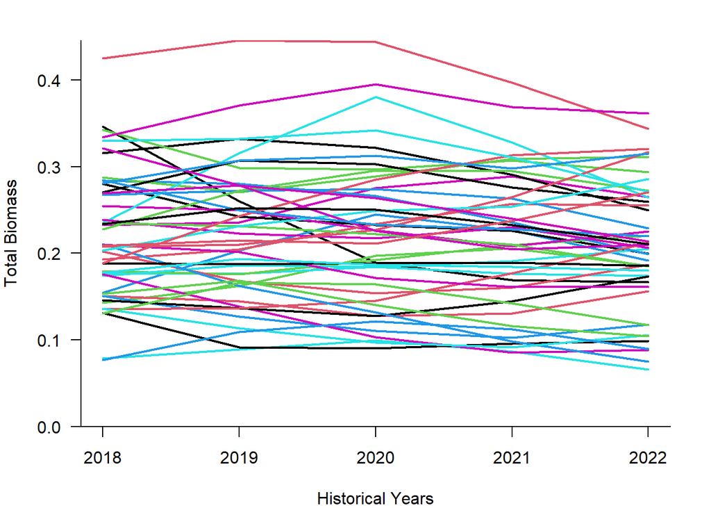

### Recruitment

#### Relative

Time-series plot of recruitment relative to R0:

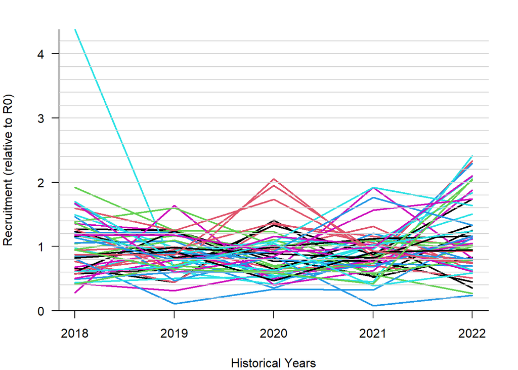

#### Absolute

Time-series plot of absolute recruitment:

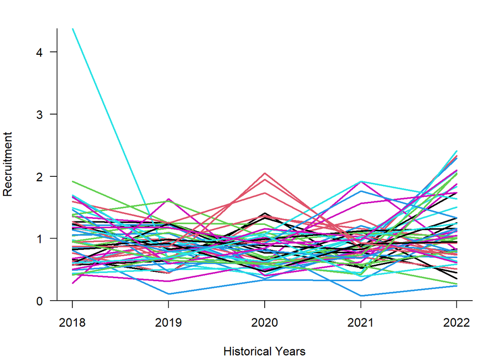

### Catch

#### Relative

Time-series of catch relative to the current year:

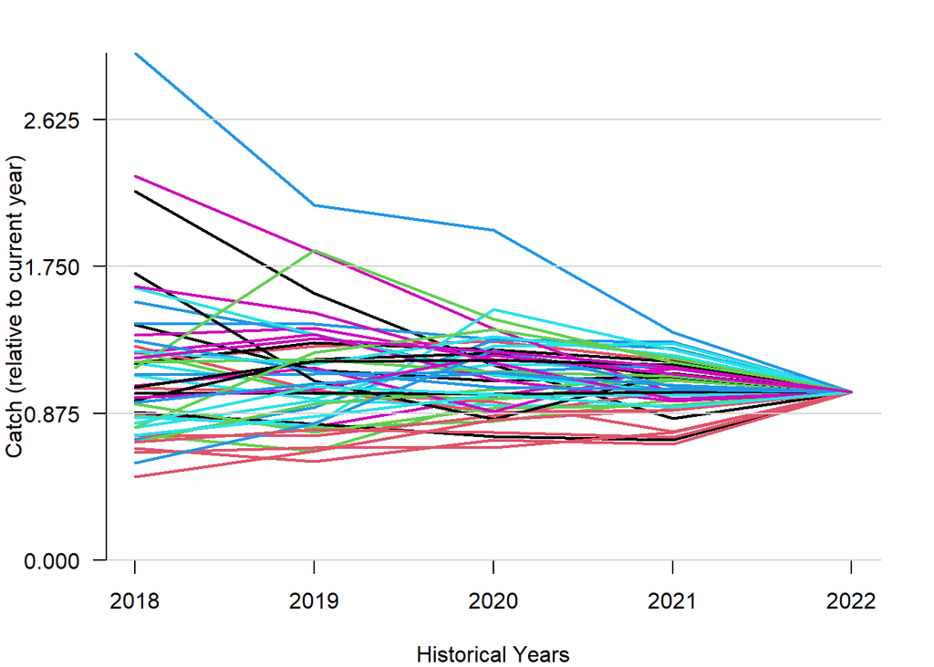

#### Absolute

Time-series of absolute catch:

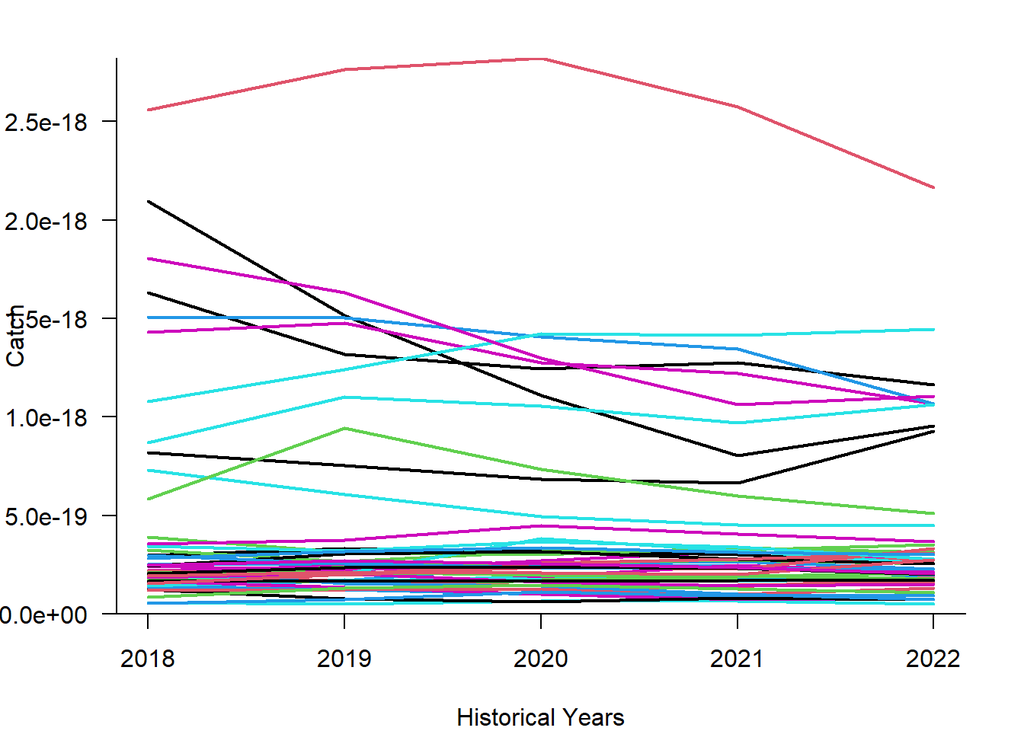

### Historical Fishing Mortality

#### Historical Time-Series

Time-series of historical fishing mortality:

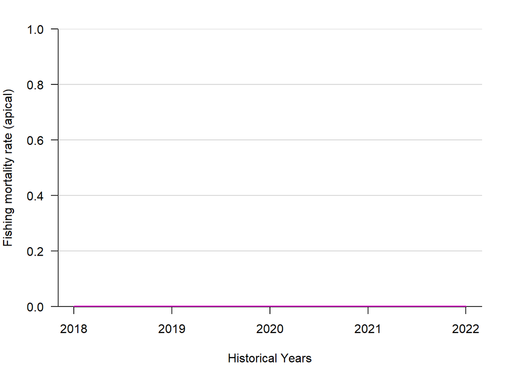

# References

Constable, A.J., de la Mare, W.K., 1996. A generalised model for evaluating yield and the long-term status of

fish stocks under conditions of uncertainty. CCAMLR Sci. 3, 31–54.

Maschette, D., Wotherspoon, S. 2021. Use of parameters within Euphausia superba GRYM simulations. WG-FSA-2021/40. Commission for the Conservation of Antarctic Marine Living Resources.

Maschette, D., Wotherspoon, S., Kawaguchi, S., Ziegler P. 2021. GRYM assessment for Subarea 48.1 Euphausia superba populations. WG-FSA-2021/39.Commission for the Conservation of Antarctic Marine Living Resources.

Pavez, C., S. Wotherspoon, D. Maschette, K. Reid, and K. Swadling. 2021. Recruitment Modelling for Euphausia Superba Stock Assessments Considering the Recurrence of Years with Low Recruitment. WG-SAM-2021/09. Commission for the Conservation of Antarctic Marine Living Resources.

Thanassekos, S., K. Reid, S. Kawaguchi, S. Wotherspoon, D. Maschette, P. Ziegler, D. Welsford, G. Watters, D.

Kinzey, C. Reiss, C. Darby, P. Trathan, S. Hill, T. Earl, S. Kasatkina and Y.-P. Ying. 2021. Grym

parameter values for Subareas 48.1, 48.2 and 48.3. WG-SAM-2021/12.